# Module4-1 Evaluating biomarkers in CCA patients (Figure 6A-6E 7A-7F)

Patipark Kueanjinda

Updated on June 22, 2020

Download patient classification data

```r
# download patient classification
setwd('C:/Users/patipark/Dropbox/CCA/module3_data2')
```

```
The working directory was changed to C:/Users/patipark/Dropbox/CCA/module3_data2 inside a notebook chunk. The working directory will be reset when the chunk is finished running. Use the knitr root.dir option in the setup chunk to change the working directory for notebook chunks.
```

```r
df.ptclass <- read.csv('GSE76297_patient_classification.csv', header = TRUE, stringsAsFactors = FALSE)
```

Download extracted core genes from previous analysis using CCA cell lines

```r
# next we will subset Genes, Expression values and test for our predictive markers
# download top predictive genes from previous analysis
setwd('C:/Users/patipark/Dropbox/CCA/module3_results')
```

```
The working directory was changed to C:/Users/patipark/Dropbox/CCA/module3_results inside a notebook chunk. The working directory will be reset when the chunk is finished running. Use the knitr root.dir option in the setup chunk to change the working directory for notebook chunks.
```

```r
Biomarkers <- read.csv('ListOfClassifierGenes.csv', header = TRUE, stringsAsFactors = FALSE)
# or
# Biomarkers <- Classifier.genes
```

```r
require(tidyverse)
myGenes <- Biomarkers %>% subset(Drug == 'Subtype_1.2')
```

Remove 1st row and change column header

```r
# note that the genes were ranked by Gini index
# remove Gini column row

topgenes <- myGenes$Gene
```

We will combine gene expression from patients with CCA cell lines. Download CCA cell line data

```r
setwd('C:/Users/patipark/Dropbox/CCA/module1_results/Tables')
```

```
The working directory was changed to C:/Users/patipark/Dropbox/CCA/module1_results/Tables inside a notebook chunk. The working directory will be reset when the chunk is finished running. Use the knitr root.dir option in the setup chunk to change the working directory for notebook chunks.
```

```r
df.explevel <- read.csv('Expression_level_ALL_20200611.csv', header = TRUE, stringsAsFactors = FALSE)
```

Prepare CCA cell line gene expression data.

```r
# convert old CCA names to new CCA names
from <- c('KKU.213','KKU.214','KKU.156','HuCCA.1','RBE','KKK.D138','HuH.28','KKU.055','KKU.100','KKK.D068','KKK.D131','HuCCT.1','SSP.25','TFK.1','YSCCC')

to <- c('KKU-213','KKU-214','KKU-156','HuCCA-1','RBE','KKK-D138','HuH-28','KKU-055','KKU-100','KKK-D068','KKK-D131','HuCCT-1','SSP-25','TFK-1','YSCCC')

map <- setNames(to,from)

# rename cell names in df.explevel
ln.col <- length(colnames(df.explevel))
b <- lapply(1:ln.col, function(n) {
  idx.name <- which(colnames(df.explevel) %in% names(map))
  if (n %in% idx.name){
    a <- as.data.frame(df.explevel[,c(n)])
    colnames(a)[1] <- map[which(names(map) == colnames(df.explevel)[n])]
  } else {
    a <- as.data.frame(df.explevel[,c(n)])
    colnames(a)[1] <- colnames(df.explevel)[n]
   }
  return(a)
})
# c-bind data
df.expr2 <- do.call(cbind,b)
# rename column
colnames(df.expr2)[1] <- 'Gene'
# reshape df.expr2
df.cca <- reshape2::melt(df.expr2, id.vars = 'Gene', variable.name = 'Cell', value.name = 'Explevel')
# assign Class according to Cell
S1 <- c('KKU-213', 'KKU-214', 'KKU-156', 'HuCCA-1', 'RBE','KKK-D138')
S2 <- c('TFK-1','YSCCC','SSP-25','KKU-100','HuCCT-1','KKK-D131','KKU-055','KKK-D068','HuH-28')
# subset data using Cells from S1 and S2
df.cca <- df.cca %>% subset(Cell %in% c(S1,S2))
# assign cell subtypes to CCA cell lines
df.cca$Class <- ifelse(df.cca$Cell %in% S1,'CCA.Subgroup1','CCA.Subgroup2')

# subset specific genes
df.cca.sub <- df.cca #%>% subset(Gene %in% topgenes)

# calculate mean of duplicated rows
# df.cca.sub <- plyr::ddply(df.cca.sub, c('Gene','Cell','Class'), plyr::numcolwise(mean))

# scale explevel per gene across patient samples
scale_this <- function(x){
  (x - mean(x, na.rm = TRUE)) / sd(x, na.rm = TRUE)
}

# rescale expression level of genes across cell lines
df.b <- df.cca.sub %>% group_by(Gene) %>% mutate(scExplevel = scale_this(Explevel))
# reshape data
m.cca <- reshape2::dcast(df.b, Gene ~ Cell, value.var = 'scExplevel')
# assign first column to rownames
m.cca <- tibble::column_to_rownames(m.cca, var = 'Gene')
cca <- m.cca
```

Download Jusakul et al. (2017) data

```r
setwd('C:/Users/patipark/Dropbox/CCA/module3_data2')
```

```
The working directory was changed to C:/Users/patipark/Dropbox/CCA/module3_data2 inside a notebook chunk. The working directory will be reset when the chunk is finished running. Use the knitr root.dir option in the setup chunk to change the working directory for notebook chunks.
```

```r
expr.apinya <- read.csv('GSE89747_CCA_Processed.csv', header = TRUE, stringsAsFactors = FALSE)

# annotation.apinya <- read.csv('GSE89747_SampleID_Map.csv', header = TRUE, stringsAsFactors = FALSE)
annotation.apinya <- read.csv('Apinya_clinical_data_tableS1.csv', header = TRUE, stringsAsFactors = FALSE)

anno.apinya.convert <- read.csv('GSE89747_SampleID_Map.csv', header = FALSE, stringsAsFactors = FALSE)
colnames(anno.apinya.convert) <- c('ID','Patient_ID')
```

Process expression data

```r
colnames(expr.apinya)[1] <- 'Gene'

expr.apinya2 <- reshape2::melt(expr.apinya, id.vars = c('Gene'), variable.name = c('Patient'), value.name = 'expr')

expr.apinya3 <- expr.apinya2 %>% group_by(Gene,Patient) %>% summarise(expr = mean(expr))
expr.apinya4 <- reshape2::dcast(expr.apinya3, Gene ~ Patient, value.var = 'expr')

expr.apinya4 <- tibble::column_to_rownames(expr.apinya4, var = 'Gene')
# convert patient ID in Apinya's data
# remove prefix X
strx <- gsub('^X','',colnames(expr.apinya4))
colnames(expr.apinya4) <- strx
id.cols <- which(!is.na(match(colnames(expr.apinya4), anno.apinya.convert$ID)))
# select non-NA column
expr.apinya4 <- expr.apinya4 %>% dplyr::select(id.cols)
```

```
Note: Using an external vector in selections is ambiguous.
i Use `all_of(id.cols)` instead of `id.cols` to silence this message.
i See <https://tidyselect.r-lib.org/reference/faq-external-vector.html>.
```

```r
colnames(expr.apinya4) <- anno.apinya.convert$Patient_ID[match(colnames(expr.apinya4), anno.apinya.convert$ID)]

# expression data received from the author were normalized (probably to matched non-tumor controls)
# scale gene expression by gene across samples
ap <- tibble::rownames_to_column(expr.apinya4, var = 'Gene')
app <- reshape2::melt(ap, id.vars = 'Gene', variable.name = 'Patient_ID', value.name = 'expr')

# subset specific genes
apinya <- app %>% group_by(Gene) %>% mutate(scexpr = scale_this(expr)) %>%
  # subset(Gene %in% topgenes) %>%
  reshape2::dcast(., Gene ~ Patient_ID, value.var = 'scexpr') %>%
  tibble::column_to_rownames(., var = 'Gene')

### Apinya
anno.apinya <- annotation.apinya %>% dplyr::select(Sample.ID,Expanded.cluster)
anno.apinya$Expanded.cluster[anno.apinya$Expanded.cluster == 'N/A'] <- NA
# remove NA rows
# anno.apinya <- anno.apinya[-c(which(is.na(anno.apinya$Expanded.cluster))),]
anno.apinya$Expanded.cluster <- as.numeric(anno.apinya$Expanded.cluster)
# anno.apinya <- anno.apinya[!is.na(anno.apinya$Expanded.cluster),]
# id rows
id.rows <- anno.apinya$Sample.ID
# create a vector
subgroup.apinya <- anno.apinya$Expanded.cluster
names(subgroup.apinya) <- anno.apinya$Sample.ID
# make the format to fit with txt file
txtformat.apinya <- data.frame('id' = names(subgroup.apinya),
                            'subgroup' = subgroup.apinya
                            )
# subset data
intersected.samples <- intersect(txtformat.apinya$id,colnames(apinya))

apinya <- apinya[,c(which(colnames(apinya) %in% intersected.samples))]
```

```r
# 117 patients with RNA seq data
# find missing genes in patient dataset
In.genes <- intersect(intersect(rownames(apinya), rownames(cca)), topgenes)
Out.genes <- topgenes[which(!topgenes %in% In.genes)]

# Add AREG TCOF1 TNFAIP2 TP53 = 0 to apinya data set
# create a zero matrix
extragenes <- matrix(data = 0, nrow = length(Out.genes), ncol = ncol(apinya)) %>% as.data.frame()

colnames(extragenes) <- colnames(apinya)
rownames(extragenes) <- Out.genes

# add zero matrix to the apinya data set
apinya <- rbind(apinya, extragenes)
```

Expression data from patients and cell lines were normalized across all samples using TDM package. There are 117 patients and 15 cell lines.

```r
# find common genes across 3 data sets
# shared.genes <- intersect(rownames(tiger),rownames(apinya))
#
# shared.genes <- intersect(shared.genes, rownames(cca))
# only cca and apinya
shared.genes <- intersect(rownames(apinya), rownames(cca))

# Transform data from microarray in bead array in Apinya to RNA-seq in CCA using traning distribution matching (TDM).
# Cross-platform normalization for microarray and RNA-seq data for machine learning application.
# DOI: 10.7717/peerj.1621

apinya2 <- apinya[c(which(rownames(apinya) %in% shared.genes)),] %>% tibble::rownames_to_column(., var = 'gene')
cca2 <- cca[c(which(rownames(cca) %in% shared.genes)),] %>% tibble::rownames_to_column(., var = 'gene')

# gene column must be 'gene'
require(TDM)
set.seed(100)
apinya.tdm <- TDM::tdm_transform(ref_data = data.table(cca2), target_data = data.table(apinya2))

cca.tdm <- cca2 #TDM::tdm_transform(ref_data = data.table(apinya2), target_data = data.table(cca2))

# add annotation
apinya3 <- apinya.tdm %>% reshape2::melt(., id.vars = 'gene', variable.name = 'ID', value.name = 'expr') %>% mutate(dataset = 'apinya')

cca3 <- cca.tdm %>% reshape2::melt(., id.vars = 'gene', variable.name = 'ID', value.name = 'expr') %>% mutate(dataset = 'cca')
# tiger3 <- tiger.tdm %>% reshape2::melt(., id.vars = 'gene', variable.name = 'ID', value.name = 'expr') %>% mutate(dataset = 'tiger')

# merge to form a large matrix
# only cca and apinya
dat.tdm <- rbind(apinya3,cca3)

dat.tdm$expr <- as.numeric(dat.tdm$expr)

dat.tdm <- dat.tdm %>% mutate(subgroup = ifelse(dataset == 'cca' & ID %in% to[1:6], 'CCA1',
                                ifelse(dataset == 'cca' & ID %in% to[7:15], 'CCA2', 'unk')))
```

Hierarchical clustering (of 45 genes) using gene expression levels form CCA patients and cell lines

```r
datin.expr <- dat.tdm %>%
  subset(gene %in% topgenes) %>% # select only candidate genes
  reshape2::dcast(., ID ~ gene, value.var = 'expr') %>% tibble::column_to_rownames(., var = 'ID')
# use gene expression data
dat.hc <- datin.expr
```

```r
# clusters only CCA cell lines
datcca.hc <- dat.hc %>% subset(rownames(.) %in% to)

hr.cca <- hclust(dist(datcca.hc, method = 'manhattan'), method = 'ward.D2')

clusters.cca.41 <- dendextend::cutree(hr.cca, k = 2)

clusters.cca.41
```

```
 HuCCA-1  HuCCT-1   HuH-28 KKK-D068 KKK-D131 KKK-D138  KKU-055  KKU-100  KKU-156  KKU-213  KKU-214      RBE   SSP-25    TFK-1    YSCCC
       1        2        2        2        2        1        2        2        1        1        1        1        2        2        2
```

```r
# test cca cell lines and patients
hr <- hclust(dist(dat.hc, method = 'manhattan'), method = 'ward.D2')

clusters.41 <- dendextend::cutree(hr, k = 2)

clusters.41
```

```
  CCA_RO_2   CCA_RO_3   CCA_RO_4   CCA_RO_5   CCA_RO_6   CCA_RO_7   CCA_SG_1   CCA_SG_2   CCA_SG_3   CCA_SG_4   CCA_SG_5   CCA_SG_6   CCA_SG_8
         1          2          2          1          1          1          1          1          1          1          2          1          2
  CCA_SG_9  CCA_SG_10  CCA_SG_11  CCA_SG_12  CCA_SG_13  CCA_SG_14  CCA_SG_15  CCA_SG_16  CCA_SG_17  CCA_SG_18  CCA_SG_19  CCA_SG_20   CCA_TH_9
         1          1          1          1          1          1          2          2          1          2          1          1          1
 CCA_TH_17  CCA_TH_18  CCA_TH_19   CCA_TH_1   CCA_TH_2   CCA_TH_3   CCA_TH_4   CCA_TH_5   CCA_TH_6   CCA_TH_7   CCA_TH_8  CCA_TH_10  CCA_TH_11
         2          1          1          2          2          1          2          2          1          2          1          1          1
 CCA_TH_12  CCA_TH_13  CCA_TH_15  CCA_TH_16  CCA_TH_21  CCA_TH_22   CCA_BR_1   CCA_BR_2  CCA_FR_13  CCA_FR_12  CCA_FR_11  CCA_FR_10   CCA_FR_9
         2          1          2          2          1          1          1          1          1          2          1          2          2
  CCA_FR_3   CCA_FR_4   CCA_FR_8   CCA_FR_7   CCA_FR_2   CCA_FR_1  CCA_FR_15  CCA_FR_16  CCA_FR_14   CCA_KR_2  CCA_RO_43  CCA_RO_42  CCA_RO_38
         1          1          1          1          1          1          1          1          1          1          2          2          1
 CCA_RO_46  CCA_RO_35  CCA_RO_31  CCA_RO_29  CCA_RO_45  CCA_RO_25  CCA_RO_23  CCA_RO_19  CCA_RO_15  CCA_RO_10  CCA_SG_48  CCA_SG_21  CCA_SG_52
         2          2          2          2          1          2          2          1          1          1          2          2          1
 CCA_SG_54   CCA_SG_7  CCA_SG_50  CCA_SG_29  CCA_SG_49  CCA_SG_24  CCA_SG_25  CCA_SG_34  CCA_SG_51  CCA_TH_23  CCA_TH_27  CCA_TH_28  CCA_TH_31
         1          2          1          1          1          2          1          1          1          2          1          1          1
 CCA_TH_32  CCA_TH_35  CCA_TH_43  CCA_TH_44 CCA_TH_130  CCA_TH_47  CCA_TH_50  CCA_TH_55  CCA_TH_56  CCA_TH_59  CCA_TH_65  CCA_TH_69  CCA_TH_70
         2          2          1          2          1          2          2          1          1          1          2          1          1
 CCA_TH_72  CCA_TH_75  CCA_TH_76  CCA_TH_79  CCA_TH_81  CCA_TH_85  CCA_TH_88  CCA_TH_89 CCA_TH_114 CCA_TH_121 CCA_TH_122 CCA_TH_127 CCA_TH_128
         2          2          1          1          1          1          2          2          1          2          1          2          2
   HuCCA-1    HuCCT-1     HuH-28   KKK-D068   KKK-D131   KKK-D138    KKU-055    KKU-100    KKU-156    KKU-213    KKU-214        RBE     SSP-25
         2          1          1          1          1          2          1          1          2          2          2          1          1
     TFK-1      YSCCC
         1          1
```

```r
# fix cluster labeling to making CCA1 cell lines as 1
clusters.41 <- ifelse(clusters.41 == 1, 2, 1)

clusters.41
```

```
  CCA_RO_2   CCA_RO_3   CCA_RO_4   CCA_RO_5   CCA_RO_6   CCA_RO_7   CCA_SG_1   CCA_SG_2   CCA_SG_3   CCA_SG_4   CCA_SG_5   CCA_SG_6   CCA_SG_8
         2          1          1          2          2          2          2          2          2          2          1          2          1
  CCA_SG_9  CCA_SG_10  CCA_SG_11  CCA_SG_12  CCA_SG_13  CCA_SG_14  CCA_SG_15  CCA_SG_16  CCA_SG_17  CCA_SG_18  CCA_SG_19  CCA_SG_20   CCA_TH_9
         2          2          2          2          2          2          1          1          2          1          2          2          2
 CCA_TH_17  CCA_TH_18  CCA_TH_19   CCA_TH_1   CCA_TH_2   CCA_TH_3   CCA_TH_4   CCA_TH_5   CCA_TH_6   CCA_TH_7   CCA_TH_8  CCA_TH_10  CCA_TH_11
         1          2          2          1          1          2          1          1          2          1          2          2          2
 CCA_TH_12  CCA_TH_13  CCA_TH_15  CCA_TH_16  CCA_TH_21  CCA_TH_22   CCA_BR_1   CCA_BR_2  CCA_FR_13  CCA_FR_12  CCA_FR_11  CCA_FR_10   CCA_FR_9
         1          2          1          1          2          2          2          2          2          1          2          1          1
  CCA_FR_3   CCA_FR_4   CCA_FR_8   CCA_FR_7   CCA_FR_2   CCA_FR_1  CCA_FR_15  CCA_FR_16  CCA_FR_14   CCA_KR_2  CCA_RO_43  CCA_RO_42  CCA_RO_38
         2          2          2          2          2          2          2          2          2          2          1          1          2
 CCA_RO_46  CCA_RO_35  CCA_RO_31  CCA_RO_29  CCA_RO_45  CCA_RO_25  CCA_RO_23  CCA_RO_19  CCA_RO_15  CCA_RO_10  CCA_SG_48  CCA_SG_21  CCA_SG_52
         1          1          1          1          2          1          1          2          2          2          1          1          2
 CCA_SG_54   CCA_SG_7  CCA_SG_50  CCA_SG_29  CCA_SG_49  CCA_SG_24  CCA_SG_25  CCA_SG_34  CCA_SG_51  CCA_TH_23  CCA_TH_27  CCA_TH_28  CCA_TH_31
         2          1          2          2          2          1          2          2          2          1          2          2          2
 CCA_TH_32  CCA_TH_35  CCA_TH_43  CCA_TH_44 CCA_TH_130  CCA_TH_47  CCA_TH_50  CCA_TH_55  CCA_TH_56  CCA_TH_59  CCA_TH_65  CCA_TH_69  CCA_TH_70
         1          1          2          1          2          1          1          2          2          2          1          2          2
 CCA_TH_72  CCA_TH_75  CCA_TH_76  CCA_TH_79  CCA_TH_81  CCA_TH_85  CCA_TH_88  CCA_TH_89 CCA_TH_114 CCA_TH_121 CCA_TH_122 CCA_TH_127 CCA_TH_128
         1          1          2          2          2          2          1          1          2          1          2          1          1
   HuCCA-1    HuCCT-1     HuH-28   KKK-D068   KKK-D131   KKK-D138    KKU-055    KKU-100    KKU-156    KKU-213    KKU-214        RBE     SSP-25
         1          2          2          2          2          1          2          2          1          1          1          2          2
     TFK-1      YSCCC
         2          2
```

```r
# change RBE to 1
clusters.41[names(clusters.41) == 'RBE'] <- 1

clusters.41
```

```
  CCA_RO_2   CCA_RO_3   CCA_RO_4   CCA_RO_5   CCA_RO_6   CCA_RO_7   CCA_SG_1   CCA_SG_2   CCA_SG_3   CCA_SG_4   CCA_SG_5   CCA_SG_6   CCA_SG_8
         2          1          1          2          2          2          2          2          2          2          1          2          1
  CCA_SG_9  CCA_SG_10  CCA_SG_11  CCA_SG_12  CCA_SG_13  CCA_SG_14  CCA_SG_15  CCA_SG_16  CCA_SG_17  CCA_SG_18  CCA_SG_19  CCA_SG_20   CCA_TH_9
         2          2          2          2          2          2          1          1          2          1          2          2          2
 CCA_TH_17  CCA_TH_18  CCA_TH_19   CCA_TH_1   CCA_TH_2   CCA_TH_3   CCA_TH_4   CCA_TH_5   CCA_TH_6   CCA_TH_7   CCA_TH_8  CCA_TH_10  CCA_TH_11
         1          2          2          1          1          2          1          1          2          1          2          2          2
 CCA_TH_12  CCA_TH_13  CCA_TH_15  CCA_TH_16  CCA_TH_21  CCA_TH_22   CCA_BR_1   CCA_BR_2  CCA_FR_13  CCA_FR_12  CCA_FR_11  CCA_FR_10   CCA_FR_9
         1          2          1          1          2          2          2          2          2          1          2          1          1
  CCA_FR_3   CCA_FR_4   CCA_FR_8   CCA_FR_7   CCA_FR_2   CCA_FR_1  CCA_FR_15  CCA_FR_16  CCA_FR_14   CCA_KR_2  CCA_RO_43  CCA_RO_42  CCA_RO_38
         2          2          2          2          2          2          2          2          2          2          1          1          2
 CCA_RO_46  CCA_RO_35  CCA_RO_31  CCA_RO_29  CCA_RO_45  CCA_RO_25  CCA_RO_23  CCA_RO_19  CCA_RO_15  CCA_RO_10  CCA_SG_48  CCA_SG_21  CCA_SG_52
         1          1          1          1          2          1          1          2          2          2          1          1          2
 CCA_SG_54   CCA_SG_7  CCA_SG_50  CCA_SG_29  CCA_SG_49  CCA_SG_24  CCA_SG_25  CCA_SG_34  CCA_SG_51  CCA_TH_23  CCA_TH_27  CCA_TH_28  CCA_TH_31
         2          1          2          2          2          1          2          2          2          1          2          2          2
 CCA_TH_32  CCA_TH_35  CCA_TH_43  CCA_TH_44 CCA_TH_130  CCA_TH_47  CCA_TH_50  CCA_TH_55  CCA_TH_56  CCA_TH_59  CCA_TH_65  CCA_TH_69  CCA_TH_70
         1          1          2          1          2          1          1          2          2          2          1          2          2
 CCA_TH_72  CCA_TH_75  CCA_TH_76  CCA_TH_79  CCA_TH_81  CCA_TH_85  CCA_TH_88  CCA_TH_89 CCA_TH_114 CCA_TH_121 CCA_TH_122 CCA_TH_127 CCA_TH_128
         1          1          2          2          2          2          1          1          2          1          2          1          1
   HuCCA-1    HuCCT-1     HuH-28   KKK-D068   KKK-D131   KKK-D138    KKU-055    KKU-100    KKU-156    KKU-213    KKU-214        RBE     SSP-25
         1          2          2          2          2          1          2          2          1          1          1          1          2
     TFK-1      YSCCC
         2          2
```

Use ggplot to draw dendrogram

```r
require(ggdendro)
# Build dendrogram object from hclust results
dend <- as.dendrogram(hr)
# Extract the data (for rectangular lines)
# Type can be "rectangle" or "triangle"
dend_data <- ggdendro::dendro_data(dend, type = "rectangle")

# What contains dend_data
names(dend_data)

# Extract data for line segments
head(dend_data$segments)
```

[output not shown]

```r
# Extract data for labels
head(dend_data$labels)
```

```r
# add CCA drug response subtypes to dend_data$labels
dend_data$labels$subtype <- clusters.41[match(dend_data$labels$label,names(clusters.41))]

dend_data$labels
```

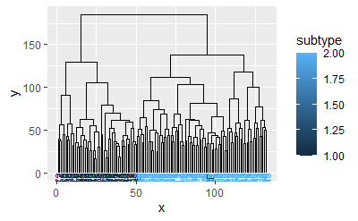

```r
# Plot line segments and add labels
p <- ggplot(dend_data$segments) +
  geom_segment(aes(x = x,
                   y = y,
                   xend = xend,
                   yend = yend))+
  geom_text(data = dend_data$labels,
            aes(x,
                y,
                label = label,
                color = subtype),
            hjust = 1, angle = 90, size = 3)
  # ylim(-10,40)

p
```

Create clinical data of CCA patients

```r
# y_auc <- known.class
patient.list <- rownames(dat.hc)

clinical.data <- annotation.apinya %>% subset(Sample.ID %in% patient.list)
# select columns
clinical.data <- clinical.data[,c(1,2,3,4,6,11,12,13,14,22)]
# rename columns
colnames(clinical.data) <- c('ID','Fluke.Infection','Country','Sex','Anatomical.subtype','TNM.Stage','Stage','Vital.state','Survival.days','Cluster')

# add predicted drug response subgroup
clinical.data$Drug.subgroup <- clusters.41[match(clinical.data$ID,names(clusters.41))]
# clinical.data$Drug.subgroup <- y_auc$glm2.pred.class[match(clinical.data$ID, y_auc$ID)]

# require suminput that indicates CCA1 or non-CCA1 of patients
# sumdrug <- suminput %>% subset(Cluster %in% c('CCA1','CCA2'))

# clinical.data$Drug.subgroup <- sumdrug$Cluster[match(clinical.data$ID,sumdrug$ID)]

# turn to numeric
# vital.state: 1 = death, 0 = survive
clinical.data$Vital.state <- as.numeric(clinical.data$Vital.state)
```

```
NAs introduced by coercion
```

```r
clinical.data$Survival.days <- as.numeric(clinical.data$Survival.days)
```

```
NAs introduced by coercion
```

```r
clinical.data$Cluster <- as.numeric(clinical.data$Cluster)
```

```
NAs introduced by coercion
```

```r
# clinical data 3 year survival
clinical.data$Vital.state3 <- ifelse(clinical.data$Survival.days > 1095, 0, 1)

clinical.data$Vital.state1 <- ifelse(clinical.data$Survival.days > 366, 0, 1)

clinical.data$Vital.state2 <- ifelse(clinical.data$Survival.days > 731, 0, 1)

# separate T from TNM stage
clinical.data$TNM <- substr(clinical.data$TNM.Stage,1,2)
clinical.data$TNM <- ifelse(clinical.data$TNM == 'Ti', 'T0',
                            ifelse(clinical.data$TNM == 'N/', NA,
                                   ifelse(clinical.data$TNM == 'Tx', NA, clinical.data$TNM)))
```

```r
require(survival)
require(survminer)

km.by.drug <- survival::survfit(Surv(Survival.days, Vital.state) ~ Drug.subgroup, data = clinical.data, conf.type = 'log-log')

km.by.cluster <- survival::survfit(Surv(Survival.days, Vital.state) ~ Cluster, data = clinical.data, conf.type = 'log-log')

km.by.tnm <- survival::survfit(Surv(Survival.days, Vital.state) ~ TNM, data = clinical.data, conf.type = 'log-log')

# Fit survival curves for each formula
# fit <- surv_fit(formulas, data = colon)

comb.km <- list(drug = km.by.drug, cluster = km.by.cluster)

# by group
fit.group <- coxph(Surv(Survival.days, Vital.state) ~ Drug.subgroup,
                   data = clinical.data)

summary(fit.group)
```

[output not shown]

```r
# calculate p value
fit.null <- surv_fit(Surv(Survival.days, Vital.state == 1) ~ 1,
                     data = clinical.data)

fit.drug <- surv_fit(Surv(Survival.days, Vital.state == 1) ~ Drug.subgroup,
                     data = clinical.data)

fit.cluster <- surv_fit(Surv(Survival.days, Vital.state == 1) ~ Cluster,
                        data = clinical.data)

fit.tnm <- surv_fit(Surv(Survival.days, Vital.state == 1) ~ TNM,
                        data = clinical.data)

# combind drug and cluster
fit.list <- list(drug = fit.drug, cluster = fit.cluster, tnm = fit.tnm)

pval.surv <- surv_pvalue(fit.list, combine = FALSE)

pval.surv$drug
```

| variable | pval | method | pval.txt |
| --- | --- | --- | --- |
| Drug.subgroup | 0.09463682 | Log-rank | p = 0.095 |

```r
# estimate 1-year survival probability
OneYear.Drug <- summary(survfit(Surv(Survival.days, Vital.state == 1) ~ Drug.subgroup,
                                data = clinical.data),
                        times = 365.25)

OneYear.Cluster <- summary(survfit(Surv(Survival.days, Vital.state == 1) ~ Cluster,
                                data = clinical.data),
                        times = 365.25)

OneYear.TNM <- summary(survfit(Surv(Survival.days, Vital.state == 1) ~ TNM,
                                data = clinical.data),
                        times = 365.25)
```

```r
# draw surivial plot using ggsurvplot from survminer package
OS1 <- survminer::ggsurvplot(comb.km,
                     data = clinical.data,
                     combine = TRUE,
                     conf.int = FALSE,
                     surv.scale = 'percent',
                     censor.shape = '+',
                     censor.size = 4,
                     palette = c('cyan','orange','dodgerblue','lightgoldenrod','olivedrab2','firebrick1'),
                     pval = FALSE,
                     pval.coord = c(1000,0.9),
                     pval.size = 3,
                     ggtheme = theme_classic2(base_family = 'Arial'),
                     font.family = 'Arial',
                     font.x = c(10, 'bold', 'black'),
                     font.y = c(10, 'bold', 'black'),
                     font.tickslab = c(8, 'plain', 'black'),
                     linetype = c('solid','solid','solid','solid','solid','solid'),
                     legend.title = '',
                     xscale = 'd_y',
                     break.time.by = 365.25,
                     legend = 'bottom',
                     legend.labs = c('CCA 1','CCA 2',
                                     'Type I','Type II',
                                     'Type III','Type IV')
                     # xlim = c(0,3000)
                     # risk.table = 'percentage',
                     # risk.table.height = 0.35,
                     # risk.table.fontsize = 0.5
)
```

[output not shown]

[output not shown]

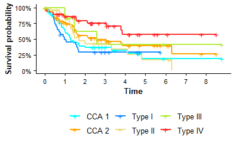

```r
OS1
```

Same as mysurv but use ggplot

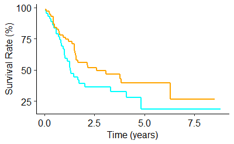

```r
sum.drug <- surv_summary(km.by.drug, data = clinical.data) %>% as.data.frame()

# conversion function
convert <- function(input){
  # convert time in days to years
  # call function decimal
  specify_decimal <- function(x, k) trimws(format(round(x, k), nsmall = k))
  input$time.year <- specify_decimal(input$time / 365.25, k = 2) %>% as.numeric()
  # convert surv to 100%
  input$surv <- input$surv * 100

  # add factor levels
  input$Drug.subgroup <- ifelse(input$Drug.subgroup == 1,'CCA1','CCA2')
  input$Drug.subgroup <- factor(input$Drug.subgroup, levels = c('CCA1','CCA2'))

  mean.survival <- input %>% group_by(Drug.subgroup) %>% summarise(mean.survival = mean(time.year))

  input$lty <- ifelse(input$Drug.subgroup == 'CCA1','CCA1','CCA2')

  return(input)
}

sum.drug <- convert(sum.drug)

OS1.1 <- ggplot() +
  geom_step(data = sum.drug,
            aes(x = time.year,
                y = surv,
                group = Drug.subgroup,
                color = Drug.subgroup,
                alpha = lty),
            size = 1) +
  scale_color_manual(values = c('CCA1' = 'cyan', 'CCA2' = 'orange')) +
  scale_shape_manual(values = c('CCA1' = 16, 'CCA2' = 16)) +
  scale_alpha_manual(values = c('drug' = 1,'molec' = 1)) +
  scale_size_manual(values = c('drug' = 1,'molec' = 1)) +
  # scale_x_continuous(breaks = seq(0,8,1), limits = c(0,5)) +
  theme_pubr() +
  theme(
    # text = element_text(family = 'Arial', size = 10),
    # axis.text = element_text(family = 'Arial', size = 8),
    # axis.title = element_text(size = 10),
    legend.position = 'none'
  ) +
  # facet_grid(lty ~ .) +
  labs(x = 'Time (years)',
       y = 'Survival Rate (%)')

# use all CCA patients drug subtype 1
OS1.1
```

```r
# subset data for Asian patients only
clinical.dataAsia <- clinical.data %>% subset(Country %in% c('Singapore','Thailand','Korea'))

# by group
Asfit.group <- coxph(Surv(Survival.days, Vital.state) ~ Drug.subgroup,
                   data = clinical.dataAsia)

summary(Asfit.group)
```

```
Call:
coxph(formula = Surv(Survival.days, Vital.state) ~ Drug.subgroup,
    data = clinical.dataAsia)

  n= 81, number of events= 44
   (1 observation deleted due to missingness)

                 coef exp(coef) se(coef)      z Pr(>|z|)
Drug.subgroup -0.3977    0.6719   0.3030 -1.313    0.189

              exp(coef) exp(-coef) lower .95 upper .95
Drug.subgroup    0.6719      1.488     0.371     1.217

Concordance= 0.559  (se = 0.04 )
Likelihood ratio test= 1.69  on 1 df,   p=0.2
Wald test            = 1.72  on 1 df,   p=0.2
Score (logrank) test = 1.75  on 1 df,   p=0.2
```

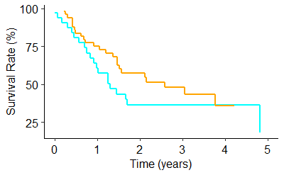

```r
# draw survival plot of Asian patients
Asian.drug <- survival::survfit(Surv(Survival.days, Vital.state) ~ Drug.subgroup,
                                data = clinical.dataAsia, conf.type = 'log-log')

sum.Asian.drug <- surv_summary(Asian.drug, data = clinical.dataAsia) %>% as.data.frame()

sum.AsDrug <- convert(sum.Asian.drug)

OS1.Asian <- ggplot() +
  geom_step(data = sum.AsDrug,
            aes(x = time.year,
                y = surv,
                group = Drug.subgroup,
                color = Drug.subgroup,
                alpha = lty),
            size = 1) +
  scale_color_manual(values = c('CCA1' = 'cyan', 'CCA2' = 'orange')) +
  scale_shape_manual(values = c('CCA1' = 16, 'CCA2' = 16)) +
  scale_alpha_manual(values = c('drug' = 1,'molec' = 1)) +
  scale_size_manual(values = c('drug' = 1,'molec' = 1)) +
  scale_x_continuous(breaks = seq(0,8,1), limits = c(0,5)) +
  theme_pubr() +
  theme(
    # text = element_text(family = 'Arial', size = 10),
    # axis.text = element_text(family = 'Arial', size = 8),
    # axis.title = element_text(size = 10),
    legend.position = 'none'
  ) +
  # facet_grid(lty ~ .) +
  labs(x = 'Time (years)',
       y = 'Survival Rate (%)')

# use all CCA patients drug subtype 1
OS1.Asian
```

```r
# subset data
clinical.dataEU <- clinical.data %>% subset(!Country %in% c('Singapore','Thailand','Korea'))

# by group
EUfit.group <- coxph(Surv(Survival.days, Vital.state) ~ Drug.subgroup,
                   data = clinical.dataEU)

summary(EUfit.group)
```

```
Call:
coxph(formula = Surv(Survival.days, Vital.state) ~ Drug.subgroup,
    data = clinical.dataEU)

  n= 33, number of events= 19
   (2 observations deleted due to missingness)

                 coef exp(coef) se(coef)      z Pr(>|z|)
Drug.subgroup -0.4769    0.6207   0.4607 -1.035    0.301

              exp(coef) exp(-coef) lower .95 upper .95
Drug.subgroup    0.6207      1.611    0.2516     1.531

Concordance= 0.554  (se = 0.062 )
Likelihood ratio test= 1.05  on 1 df,   p=0.3
Wald test            = 1.07  on 1 df,   p=0.3
Score (logrank) test = 1.09  on 1 df,   p=0.3
```

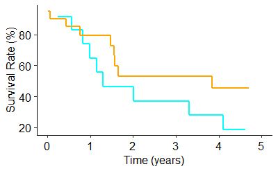

```r
# Draw survival plot for non-Asian group
EU.drug <- survival::survfit(Surv(Survival.days, Vital.state) ~ Drug.subgroup,
                                data = clinical.dataEU, conf.type = 'log-log')

sum.EU.drug <- surv_summary(EU.drug, data = clinical.dataEU) %>% as.data.frame()

sum.EUDrug <- convert(sum.EU.drug)

OS1.EU <- ggplot() +
  geom_step(data = sum.EUDrug,
            aes(x = time.year,
                y = surv,
                group = Drug.subgroup,
                color = Drug.subgroup,
                alpha = lty),
            size = 1) +
  scale_color_manual(values = c('CCA1' = 'cyan', 'CCA2' = 'orange')) +
  scale_shape_manual(values = c('CCA1' = 16, 'CCA2' = 16)) +
  scale_alpha_manual(values = c('drug' = 1,'molec' = 1)) +
  scale_size_manual(values = c('drug' = 1,'molec' = 1)) +
  scale_x_continuous(breaks = seq(0,8,1), limits = c(0,5)) +
  theme_pubr() +
  theme(
    # text = element_text(family = 'Arial', size = 10),
    # axis.text = element_text(family = 'Arial', size = 8),
    # axis.title = element_text(size = 10),
    legend.position = 'none'
  ) +
  # facet_grid(lty ~ .) +
  labs(x = 'Time (years)',
       y = 'Survival Rate (%)')

# use all CCA patients drug subtype 1
OS1.EU
```

```r
# subset data for Thailand or OV-infected patients only
clinical.dataTH <- clinical.data %>% subset(Country %in% c('Thailand'))

# by group
THfit.group <- coxph(Surv(Survival.days, Vital.state3) ~ Drug.subgroup,
                   data = clinical.dataTH)

summary(THfit.group)
```

```
Call:
coxph(formula = Surv(Survival.days, Vital.state3) ~ Drug.subgroup,
    data = clinical.dataTH)

  n= 49, number of events= 41
   (1 observation deleted due to missingness)

                 coef exp(coef) se(coef)    z Pr(>|z|)
Drug.subgroup -0.2192    0.8032   0.3132 -0.7    0.484

              exp(coef) exp(-coef) lower .95 upper .95
Drug.subgroup    0.8032      1.245    0.4347     1.484

Concordance= 0.534  (se = 0.043 )
Likelihood ratio test= 0.49  on 1 df,   p=0.5
Wald test            = 0.49  on 1 df,   p=0.5
Score (logrank) test = 0.49  on 1 df,   p=0.5
```

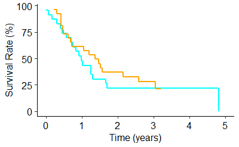

```r
# Draw survival plot for Thai or OV-infected group
TH.drug <- survival::survfit(Surv(Survival.days, Vital.state) ~ Drug.subgroup,
                                data = clinical.dataTH, conf.type = 'log-log')

sum.TH.drug <- surv_summary(TH.drug, data = clinical.dataTH) %>% as.data.frame()

sum.THDrug <- convert(sum.TH.drug)

OS1.TH <- ggplot() +
  geom_step(data = sum.THDrug,
            aes(x = time.year,
                y = surv,
                group = Drug.subgroup,
                color = Drug.subgroup,
                alpha = lty),
            size = 1) +
  scale_color_manual(values = c('CCA1' = 'cyan', 'CCA2' = 'orange')) +
  scale_shape_manual(values = c('CCA1' = 16, 'CCA2' = 16)) +
  scale_alpha_manual(values = c('drug' = 1,'molec' = 1)) +
  scale_size_manual(values = c('drug' = 1,'molec' = 1)) +
  scale_x_continuous(breaks = seq(0,8,1), limits = c(0,5)) +
  theme_pubr() +
  theme(
    # text = element_text(family = 'Arial', size = 10),
    # axis.text = element_text(family = 'Arial', size = 8),
    # axis.title = element_text(size = 10),
    legend.position = 'none'
  ) +
  # facet_grid(lty ~ .) +
  labs(x = 'Time (years)',
       y = 'Survival Rate (%)')

# use all CCA patients drug subtype 1
OS1.TH
```

Draw a heatmap from the above unsupervised clustering using Complex heatmap. Input data was TDM-normalized expression matrix of CCA patients+cell lines.

```r
require(ComplexHeatmap)
# use gene expression of 45 genes from both CCA cell lines and patients
datin <- t(dat.hc) %>% as.data.frame()

# move rowname to column
datin2 <- tibble::rownames_to_column(datin, var = 'Gene')
# reshape dataframe
datannot <- reshape2::melt(datin2, id.vars = 'Gene', variable.name = 'ID', value.name = 'expr')
# add dataset annotation
datannot$dataset <- ifelse(datannot$ID %in% to, 'cca','apinya')
# add ID annotation
datannot$subgroup <- ifelse(datannot$ID %in% to[1:6],'CCA1',
                            ifelse(datannot$ID %in% to[7:15],'CCA2','unk'))
# add molecular subgroup annotation to patients
datannot$apinya.subgroup <- clinical.data$Cluster[match(datannot$ID,clinical.data$ID)]
```

Prepare expression matrix for a heatmap plot.

```r
# subset only apinya and CCA columns
ref.col <- datannot %>% select(c('ID','dataset','subgroup','apinya.subgroup')) %>% unique()

# subset apinya cca patient dataset only
ref.apinya <- ref.col %>% subset(dataset == 'apinya' & !is.na(apinya.subgroup))
# subset cca cell line dataset only
ref.cca <- ref.col %>% subset(dataset == 'cca')
# join both datasets together
ref.col <- rbind(ref.apinya,ref.cca)
# as a result, there were 115 samples in combination (100 patients + 15 cell lines)

# subset only apinya and cca data sets and rename as apcc (apinya+cell line)
apcc <- ref.col %>% subset(dataset %in% c('apinya','cca'))

# use the list from apcc and select expression data by columns
datin.apcc <- datin[,which(colnames(datin) %in% apcc$ID)] %>% as.data.frame()

# then limit data to only 45 genes that are selected biomarkers
datin.apcc.sub <- datin.apcc %>% subset(rownames(.) %in% topgenes)
```

```r
# now apply scale() function to the expression level of each gene
#across all 115 samples (by row, MARGIN = 1)
# no scale() applied
# myMatrix <- datin.apcc.sub
# scale() applied
myMatrix <- apply(X = datin.apcc.sub,MARGIN = 1,FUN = scale) %>% t() %>% as.data.frame()

# add column header (sample ID)
colnames(myMatrix) <- colnames(datin.apcc.sub)
```

Examine percent variance explained using PCA.

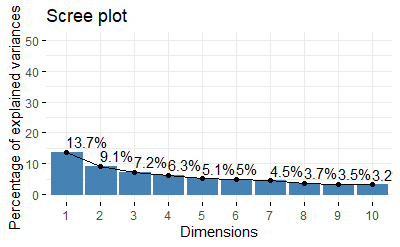

```r
require(factoextra)
require(FactoMineR)
res.pca <- PCA(t(myMatrix), graph = FALSE)

fviz_screeplot(res.pca, addlabels = TRUE, ylim = c(0, 50))
```

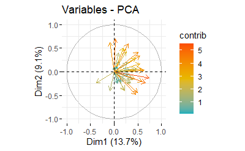

```r
fviz_pca_var(res.pca, col.var="contrib",
             gradient.cols = c("#00AFBB", "#E7B800", "#FC4E07"),
             repel = TRUE # Avoid text overlapping
             )
```

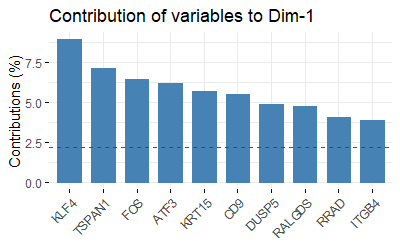

```r
# Contributions of variables to PC1
fviz_contrib(res.pca, choice = "var", axes = 1, top = 10)
```

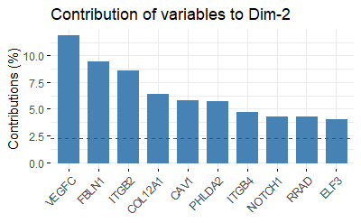

```r
# Contributions of variables to PC2
fviz_contrib(res.pca, choice = "var", axes = 2, top = 10)
```

```r
# Extract the results for individuals
ind <- get_pca_ind(res.pca)

ind.res <- fviz_pca_ind(res.pca, col.ind = "cos2",
             gradient.cols = c("#00AFBB", "#E7B800", "#FC4E07"),
             repel = TRUE # Avoid text overlapping (slow if many points)
             )

# extract Dim.1, Dim.2, cos2 and add predicted CCA subtype
ind.dat <- as.data.frame(ind$coord)
# extract cos2 to individual dataframe
ind.cos2 <- as.data.frame(ind$cos2)
# add cos2 values to individual dataframe
ind.dat$cos2.Dim1 <- ind.cos2$Dim.1[match(rownames(ind.dat), rownames(ind.cos2))]
# add CCA drug response subtype to individual dataframe
ind.dat$CCAsubtype <- ordertab$Cluster[match(rownames(ind.dat), ordertab$ID)]
# move rowname to column
ind.dat <- tibble::rownames_to_column(ind.dat, var = 'ID')
# change from 1 and 2 to CCA1 and CCA2 and add factor level to CCA subtype
ind.dat$CCAsubtype <- ifelse(ind.dat$CCAsubtype == 1,'CCA1','CCA2')
ind.dat$CCAsubtype <- factor(ind.dat$CCAsubtype, levels = c('CCA1','CCA2'))

ind.dat.cells <- ind.dat %>% subset(ID %in% to)
ind.dat.pts <- ind.dat %>% subset(!ID %in% to)

# draw PCA plot
require(ggrepel)
ind.pca <- ggplot(ind.dat.cells,
             aes(x = Dim.1,
                 y = Dim.2,
                 shape = CCAsubtype,
                 color = cos2.Dim1)) +
  geom_point() +
  geom_text_repel(aes(label = ID))

ind.pca <- ind.pca + geom_point(data = ind.dat.pts,
                 aes(x = Dim.1,
                     y = Dim.2,
                     shape = CCAsubtype,
                     color = cos2.Dim1))
```

```r
# select data for svm data input
svm.ind <- ind.dat %>%
  dplyr::select(ID,Dim.1,Dim.2,CCAsubtype) %>%
  # subset(ID %in% to) %>%
  `rownames<-`(.,NULL)

# move ID column to rowname
svm.ind <- tibble::column_to_rownames(svm.ind, var = 'ID')

# make another dataframe for cell lines
svm.cell <- ind.dat %>%
  dplyr::select(ID,Dim.1,Dim.2,CCAsubtype) %>%
  subset(ID %in% to) %>%
  `rownames<-`(.,NULL)

svm.cell <- tibble::column_to_rownames(svm.cell, var = 'ID')

# build a SVM model. Scale is FALSE because tSNEs are already scaled.
set.seed(100)
# fit SVM model using non-linear kernel for all 115 samples
svm.ind.fit <- e1071::svm(CCAsubtype ~ .,
                      data = svm.ind,
                      scale = FALSE,
                      kernel = 'radial'
                      )

# fit SVM model using non-linear kernel for all 15 samples
svm.cell.fit <- e1071::svm(CCAsubtype ~ .,
                      data = svm.cell,
                      scale = FALSE,
                      kernel = 'linear'
                      )

# function for building grid matrix for drawing a boundary line
make.grid <- function(x, n = 100) {
  grange = apply(x, 2, range)
  x1 = seq(from = grange[1,1], to = grange[2,1], length = n)
  x2 = seq(from = grange[1,2], to = grange[2,2], length = n)
  expand.grid(X1 = x1, X2 = x2)
}

# make grid from svm.ind.fit
xdat.ind <- svm.ind %>% dplyr::select(Dim.1,Dim.2)

# make grid based on samples in svm.ind
xgrid.ind <- make.grid(xdat.ind)

# change column names
colnames(xgrid.ind) <- c('Dim.1','Dim.2')

# use non-linear SVM from cell lines to predict drug response subtypes of objects in the grid matrix
ygrid.ind <- predict(svm.ind.fit, xgrid.ind[,c('Dim.1','Dim.2')])

# ygrid.ind <- predict(svm.cell.fit, xgrid.ind[,c('Dim.1','Dim.2')]) # linear-SVM

# add predicted subtype
xgrid.ind$group <- ygrid.ind

# change to C1 or C2
xgrid.ind$group <- ifelse(xgrid.ind$group == 1,'C1','C2')

# calculate z value
func <- predict(svm.cell.fit, xgrid.ind[,c('Dim.1','Dim.2')], decision.values = TRUE)

func <- attributes(func)$decision

xgrid.ind$z <- func
```

If the model is linear SVM, we can draw euclidean distance from the regression line.

```r
# find slope and intercept of the boundary
# build weight vector
w <- t(svm.ind.fit$coefs) %*% svm.ind.fit$SV

# slope = -w[1]/w[2]
# calculate slope and save it to a variable
slope_1 <- -w[1]/w[2]

# intercept = svm.ind.fit$rho/w[2]
# calculate intercept and save it to a variable
intercept_1 <- svm.ind.fit$rho/w[2]

# calculate perpendicular distance from point 'a' to a line with 'slope' and 'intercept'
dist_point_line <- function(a, slope, intercept) {
    b = c(1, intercept+slope)
    c = c(-intercept/slope,0)
    v1 <- b - c
    v2 <- a - b
    m <- cbind(v1,v2)
    return(abs(det(m))/sqrt(sum(v1*v1)))
}

eudis <- apply(ind.my, 1, function(x) dist_point_line(as.numeric(x[2:3]), slope = slope_1, intercept = intercept_1))
```

[output not shown]

Predict drug response subtype of patients

```r
# use non-linear SVM model (svm.cell.fit) to predict drug response subtype of patients
# subset patient data
svm.pt <- svm.ind %>% subset(!rownames(.) %in% to)

# perform prediction
pred.CCApt <- predict(svm.ind.fit, svm.pt[,c('Dim.1','Dim.2')], decision.values = TRUE)

# add SVM-predicted subtype to the dataframe
svm.pt$CCAsubtype.SVM <- pred.CCApt
```

Does the SVM.cell.fit model give accurate prediction result compared to hierarchical clustering?

```r
# use caret to measure prediction accuracy
# add factor levels
svm.pt$CCAsubtype <- as.factor(svm.pt$CCAsubtype)
svm.pt$CCAsubtype.SVM <- as.factor(svm.pt$CCAsubtype.SVM)

# use CCA subtypes from hierachical clustering as reference
pred.acc.pt <- caret::confusionMatrix(data = svm.pt$CCAsubtype.SVM,
                       reference = svm.pt$CCAsubtype,
                       mode = 'prec_recall')

pred.acc.pt
```

```
Confusion Matrix and Statistics

          Reference
Prediction CCA1 CCA2
      CCA1   17    3
      CCA2    7   73

               Accuracy : 0.9
                 95% CI : (0.8238, 0.951)
    No Information Rate : 0.76
    P-Value [Acc > NIR] : 0.0003075

                  Kappa : 0.7093

 Mcnemar's Test P-Value : 0.3427817

              Precision : 0.8500
                 Recall : 0.7083
                     F1 : 0.7727
             Prevalence : 0.2400
         Detection Rate : 0.1700
   Detection Prevalence : 0.2000
      Balanced Accuracy : 0.8344

       'Positive' Class : CCA1
```

```r
# use non-linear SVM model (svm.cell.fit) to predict drug response subtype of patients
# subset patient data
svm.cca <- svm.ind %>% subset(rownames(.) %in% to)

# perform prediction
pred.CCAcell <- predict(svm.ind.fit, svm.cca[,c('Dim.1','Dim.2')], decision.values = TRUE)

# add SVM-predicted subtype to the dataframe
svm.cca$CCAsubtype.SVM <- pred.CCAcell

# use caret to measure prediction accuracy
# add factor levels
svm.cca$CCAsubtype <- as.factor(svm.cca$CCAsubtype)
svm.cca$CCAsubtype.SVM <- as.factor(svm.cca$CCAsubtype.SVM)

# use CCA subtypes from hierachical clustering as reference
pred.acc.cca <- caret::confusionMatrix(data = svm.cca$CCAsubtype.SVM,
                       reference = svm.cca$CCAsubtype,
                       mode = 'prec_recall')

pred.acc.cca
```

```
Confusion Matrix and Statistics

          Reference
Prediction CCA1 CCA2
      CCA1    4    1
      CCA2    1    9

               Accuracy : 0.8667
                 95% CI : (0.5954, 0.9834)
    No Information Rate : 0.6667
    P-Value [Acc > NIR] : 0.07936

                  Kappa : 0.7

 Mcnemar's Test P-Value : 1.00000

              Precision : 0.8000
                 Recall : 0.8000
                     F1 : 0.8000
             Prevalence : 0.3333
         Detection Rate : 0.2667
   Detection Prevalence : 0.3333
      Balanced Accuracy : 0.8500

       'Positive' Class : CCA1
```

Draw AUC plot to display the prediction accuracy of non-linear SVM model

```r
# build a dataframe of prediction accuracy
acc.table <- data.frame('Dataset' = c('Patient','Cell'),
           'Accuracy' = c(pred.acc.pt$byClass[11],
                          pred.acc.cca$byClass[11]))

FigS7C <- ggplot(acc.table,
       aes(x = Dataset,
           y = Accuracy)) +
  geom_col() +
  theme_pubr() +
  labs(x = '',
       y = 'Prediction accuracy') +
  geom_text(aes(label = round(Accuracy,2)), nudge_x = 0, nudge_y = 0.05)
```

Save prediction accuracy of non-linear SVM as Figure S6C

```r
setwd('C:/Users/patipark/Dropbox/CCA project/CCA RNA-seq/NewGeneSet_Module_InitialAnalysis/Figure_5A_files')
ggsave(FigS7C,
       filename = 'FigureS6C_PredictionAccuracy_20201001.pdf',
       height = 3,
       width = 2.5,
       units = 'in',
       device = cairo_pdf)
dev.off()
```

```r
# create data for drug and molecular subgroups
ind.my <- tibble::rownames_to_column(svm.ind, var = 'ID')

ind.my$group <- clinical.data$Cluster[match(ind.my$ID,clinical.data$ID)]

ind.my$group <- ifelse(ind.my$ID %in% to[1:6], 'C1',
                        ifelse(ind.my$ID %in% to[7:15], 'C2', ind.my$group))

ind.my <- ind.my %>% mutate(group = case_when(group == 1 ~ 'I',
                                                group == 2 ~ 'II',
                                                group == 3 ~ 'III',
                                                group == 4 ~ 'IV',
                                                TRUE ~ group),
                              dataset = ifelse(ID %in% to, 'cca', 'patient'))

# add factor level
ind.my$group <- factor(ind.my$group, levels = c('C1','C2','I','II','III','IV','unk'))
ind.my$dataset <- factor(ind.my$dataset, levels = c('cca','patient'))

# add factor level to grid data
xgrid.ind$group <- factor(xgrid.ind$group, levels = c('C1','C2','I','II','III','IV','unk'))

# subset CCA data
ind.cca <- ind.my %>% subset(ID %in% to)

# subset patient data
ind.pt <- ind.my %>% subset(!ID %in% to)
```

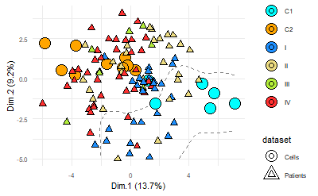

```r
require(ggrepel)
figS7B.ind <- ggplot() +
  # geom_tile(data = xgrid,
  #           aes(x = tSNE1,
  #               y = tSNE2,
  #               fill = group),
  #           alpha = 0.1) +
  geom_contour(data = xgrid.ind,
               aes(x = Dim.1,
                   y = Dim.2,
                   z = z), bins = 2, color = 'gray50', lty = 'dashed') +
  geom_point(data = ind.cca,
             aes(x = Dim.1,
                 y = Dim.2,
                 # color = group,
                 fill = group,
                 shape = dataset),
             size = 5) +
  geom_point(data = ind.pt,
             aes(x = Dim.1,
                 y = Dim.2,
                 # color = group,
                 fill = group,
                 shape = dataset),
             size = 2) +
  scale_fill_manual(values = c('C1' = 'cyan','C2' = 'orange',
                               'I' = 'dodgerblue','II' = 'lightgoldenrod',
                               'III' = 'olivedrab2','IV' = 'firebrick1',
                               'unk' = 'gray50')) +
  # scale_color_manual(values = c('C1' = 'cyan','C2' = 'orange',
  #                               'I' = 'dodgerblue','II' = 'lightgoldenrod',
  #                               'III' = 'olivedrab2','IV' = 'firebrick1',
  #                               'unk' = 'gray50')) +
  scale_shape_manual(values = c('cca' = 21,
                                'patient' = 24),
                     labels = c('cca' = 'Cells',
                                'patient' = 'Patients')) +
  geom_text_repel(data = ind.cca,
                  aes(x = Dim.1,
                      y = Dim.2,
                      label = ID),
                  size = 3,
                  nudge_x = 0.2,
                  nudge_y = 0.2) +
  labs(
    x = 'Dim.1 (13.7%)',
    y = 'Dim.2 (9.2%)'
  ) +
  theme_minimal() +
  theme(
    # text = element_text(family = 'Arial'),
    legend.title = element_text(size = 8),
    legend.text = element_text(size = 6),
    axis.text = element_text(size = 6),
    axis.title = element_text(size = 8),
    legend.direction = 'vertical'
  ) +

  guides(fill = guide_legend(override.aes = list(shape = 21)))

figS7B.ind
```

```r
setwd('C:/Users/patipark/Dropbox/CCA project/CCA RNA-seq/NewGeneSet_Module_InitialAnalysis/Figure_5A_files')
ggsave(figS7B.ind,
       filename = 'FigureS6B_PCAradialSVM_20200923.pdf',
       height = 5,
       width = 6,
       units = 'in',
       device = cairo_pdf)
dev.off()
```

Use linear SVM to predict decision boundary (based on 15 CCA cell lines).

```r
# select data for svm data input
svm.cell <- ind.dat %>% dplyr::select(ID,Dim.1,Dim.2,CCAsubtype) %>% subset(ID %in% to) %>% `rownames<-`(., NULL)
# move ID column to rowname
svm.cell <- tibble::column_to_rownames(svm.cell, var = 'ID')

# build a SVM model. Scale is FALSE because tSNEs are already scaled.
set.seed(100)
svm.cell.fit <- e1071::svm(CCAsubtype ~ .,
                      data = svm.cell,
                      scale = FALSE,
                      kernel = 'linear'
                      )

# build grid for boundary line
make.grid <- function(x, n = 100) {
  grange = apply(x, 2, range)
  x1 = seq(from = grange[1,1], to = grange[2,1], length = n)
  x2 = seq(from = grange[1,2], to = grange[2,2], length = n)
  expand.grid(X1 = x1, X2 = x2)
}

xdat.cell <- svm.ind %>% dplyr::select(Dim.1,Dim.2)

xgrid.cell <- make.grid(xdat.cell)

colnames(xgrid.cell) <- c('Dim.1','Dim.2')

ygrid.cell <- predict(svm.cell.fit, xgrid.cell[,c('Dim.1','Dim.2')])

xgrid.cell$group <- ygrid.cell

xgrid.cell$group <- ifelse(xgrid.cell$group == 1,'C1','C2')

func <- predict(svm.cell.fit, xgrid.cell[,c('Dim.1','Dim.2')], decision.values = TRUE)

func <- attributes(func)$decision

xgrid.cell$z <- func

# find slope and intercept of the boundary
# build weight vector
w <- t(svm.cell.fit$coefs) %*% svm.cell.fit$SV

# slope = -w[1]/w[2]
# calculate slope and save it to a variable
slope_1 <- -w[1]/w[2]

# intercept = svm.ind.fit$rho/w[2]
# calculate intercept and save it to a variable
intercept_1 <- svm.cell.fit$rho/w[2]

# calculate perpendicular distance from point 'a' to a line with 'slope' and 'intercept'
dist_point_line <- function(a, slope, intercept) {
    b = c(1, intercept+slope)
    c = c(-intercept/slope,0)
    v1 <- b - c
    v2 <- a - b
    m <- cbind(v1,v2)
    return(abs(det(m))/sqrt(sum(v1*v1)))
}

# subset data from ind.my
cell.my <- ind.my #%>% subset(ID %in% to)

eudis <- apply(cell.my, 1, function(x) dist_point_line(as.numeric(x[2:3]), slope = slope_1, intercept = intercept_1))

cell.my <- tibble::add_column(cell.my, eudis, .after = 3)

# CCA1 from hight to low
cell.my.cca1 <- cell.my %>% subset(CCAsubtype == 'CCA1') %>% arrange(desc(eudis))

# CCA2 from low to high
cell.my.cca2 <- cell.my %>% subset(CCAsubtype == 'CCA2') %>% arrange(eudis)

# combine euclidean distance of CCA1 and CCA2 groups
cell.my.eudis <- rbind(cell.my.cca1,cell.my.cca2)

# subset CCA data
cell.cca <- cell.my %>% subset(ID %in% to)
```

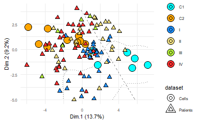

```r
require(ggrepel)
figS7B.cell <- ggplot() +
  # geom_tile(data = xgrid,
  #           aes(x = tSNE1,
  #               y = tSNE2,
  #               fill = group),
  #           alpha = 0.1) +
  geom_contour(data = xgrid.cell,
               aes(x = Dim.1,
                   y = Dim.2,
                   z = z), bins = 2, color = 'gray50', lty = 'dashed') +
    geom_contour(data = xgrid.ind,
               aes(x = Dim.1,
                   y = Dim.2,
                   z = z), bins = 2, color = 'gray50', lty = 'dotted') +
  geom_point(data = cell.cca,
             aes(x = Dim.1,
                 y = Dim.2,
                 # color = group,
                 fill = group,
                 shape = dataset),
             size = 5) +
    geom_point(data = ind.pt,
             aes(x = Dim.1,
                 y = Dim.2,
                 # color = group,
                 fill = group,
                 shape = dataset),
             size = 2) +
  scale_fill_manual(values = c('C1' = 'cyan','C2' = 'orange',
                               'I' = 'dodgerblue','II' = 'lightgoldenrod',
                               'III' = 'olivedrab2','IV' = 'firebrick1',
                               'unk' = 'gray50')) +
  # scale_color_manual(values = c('C1' = 'cyan','C2' = 'orange',
  #                               'I' = 'dodgerblue','II' = 'lightgoldenrod',
  #                               'III' = 'olivedrab2','IV' = 'firebrick1',
  #                               'unk' = 'gray50')) +
  scale_shape_manual(values = c('cca' = 21,
                                'patient' = 24),
                     labels = c('cca' = 'Cells',
                                'patient' = 'Patients')) +
  geom_text_repel(data = cell.cca,
                  aes(x = Dim.1,
                      y = Dim.2,
                      label = ID),
                  size = 3,
                  nudge_x = 0.2,
                  nudge_y = 0.2) +
  labs(
    x = 'Dim.1 (13.7%)',
    y = 'Dim.2 (9.2%)'
  ) +
  theme_minimal() +
  theme(
    # text = element_text(family = 'Arial'),
    legend.title = element_text(size = 8),
    legend.text = element_text(size = 6),
    axis.text = element_text(size = 6),
    axis.title = element_text(size = 8),
    legend.direction = 'vertical'
  ) +

  guides(fill = guide_legend(override.aes = list(shape = 21)))

figS7B.cell
```

Save FigureS7B (used CCA cell lines for linear SVM)

```r
setwd('C:/Users/patipark/Dropbox/CCA project/CCA RNA-seq/NewGeneSet_Module_InitialAnalysis/Figure_5A_files')
ggsave(figS7B.cell,
       filename = 'FigureS7B_PCAlinearVSradialSVM_CCAonly_20200929.pdf',
       height = 5,
       width = 6,
       units = 'in',
       device = cairo_pdf)
dev.off()
```

```r
# use unsupervised hierarhical clustering to classify cca patients
hr <- hclust(dist(t(myMatrix), method = 'euclidean',), method = 'ward.D2')
clusters <- dendextend::cutree(hr, k = 2)

# this cluster will be further used.
clusters
```

```
  CCA_RO_2   CCA_RO_3   CCA_RO_4   CCA_RO_5   CCA_RO_6   CCA_RO_7   CCA_SG_1   CCA_SG_2   CCA_SG_3   CCA_SG_4   CCA_SG_5   CCA_SG_6   CCA_SG_8
         1          1          1          2          2          2          2          2          2          2          1          2          1
  CCA_SG_9  CCA_SG_10  CCA_SG_11  CCA_SG_12  CCA_SG_13  CCA_SG_14  CCA_SG_15  CCA_SG_16  CCA_SG_17  CCA_SG_18  CCA_SG_19  CCA_SG_20  CCA_TH_17
         2          2          2          2          2          2          1          2          1          1          1          2          1
 CCA_TH_18  CCA_TH_19   CCA_TH_1   CCA_TH_2   CCA_TH_3   CCA_TH_5   CCA_TH_7   CCA_TH_8  CCA_TH_10  CCA_TH_11  CCA_TH_13  CCA_TH_15  CCA_TH_21
         1          2          1          1          2          1          1          1          2          2          2          1          2
 CCA_TH_22   CCA_BR_1   CCA_BR_2  CCA_FR_13  CCA_FR_12  CCA_FR_11  CCA_FR_10   CCA_FR_9   CCA_FR_3   CCA_FR_4   CCA_FR_8   CCA_FR_7   CCA_FR_2
         1          2          1          2          1          2          1          1          1          2          2          1          2
  CCA_FR_1  CCA_FR_15  CCA_FR_16  CCA_FR_14   CCA_KR_2  CCA_RO_42  CCA_RO_38  CCA_RO_46  CCA_RO_35  CCA_RO_31  CCA_RO_29  CCA_RO_25  CCA_RO_23
         2          2          2          2          1          1          2          1          1          1          1          1          1
 CCA_RO_19  CCA_RO_15  CCA_RO_10  CCA_SG_48  CCA_SG_21  CCA_SG_54   CCA_SG_7  CCA_SG_50  CCA_SG_29  CCA_SG_49  CCA_SG_24  CCA_SG_25  CCA_SG_34
         2          2          2          1          1          2          1          2          1          2          1          2          2
 CCA_TH_23  CCA_TH_27  CCA_TH_28  CCA_TH_31  CCA_TH_43  CCA_TH_44 CCA_TH_130  CCA_TH_47  CCA_TH_50  CCA_TH_55  CCA_TH_59  CCA_TH_65  CCA_TH_69
         1          2          2          1          2          1          2          1          1          1          1          1          2
 CCA_TH_72  CCA_TH_75  CCA_TH_79  CCA_TH_81  CCA_TH_85 CCA_TH_121 CCA_TH_122 CCA_TH_127 CCA_TH_128    HuCCA-1    HuCCT-1     HuH-28   KKK-D068
         1          1          1          2          1          1          1          2          1          1          1          2          2
  KKK-D131   KKK-D138    KKU-055    KKU-100    KKU-156    KKU-213    KKU-214        RBE     SSP-25      TFK-1      YSCCC
         1          2          2          2          1          1          1          2          2          2          2
```

Rule for CCA1 group

```r
# if CCA1 cells are named as 1
# do not change
# if CCA1 cells are named as 2
# change to 1
CCA1.list <- c('KKU-156','KKU-213','KKU-214','HuCCA-1','KKK-D138','RBE')
CCA2.list <- c('HuCCT-1','HuH-28','KKK-D068','KKK-D131','KKU-055','KKU-100','SSP-25','TFK-1','YSCCC')
if (clusters['KKU-156'] == 1 & clusters['KKU-213'] == 1 & clusters['KKU-214'] == 1) {
  cls1 <- ifelse(clusters[CCA1.list] != 1, clusters[CCA1.list] <- 1, clusters[CCA1.list])
  cls2 <- ifelse(clusters[CCA2.list] != 2, clusters[CCA2.list] <- 2, clusters[CCA2.list])
  cls3 <- clusters[which(!names(clusters) %in% c(CCA1.list,CCA2.list))]
} else {
cls1 <- ifelse(clusters[CCA1.list] != 1, clusters[CCA1.list] <- 1, clusters[CCA1.list])
cls2 <- ifelse(clusters[CCA2.list] != 2, clusters[CCA2.list] <- 2, clusters[CCA2.list])
cls3 <- ifelse(clusters[which(!names(clusters) %in% c(CCA1.list,CCA2.list))] == 2,1,2)
}

clusters <- c(cls1,cls2,cls3)

clusters
```

```
   KKU-156    KKU-213    KKU-214    HuCCA-1   KKK-D138        RBE    HuCCT-1     HuH-28   KKK-D068   KKK-D131    KKU-055    KKU-100     SSP-25
         1          1          1          1          1          1          2          2          2          2          2          2          2
     TFK-1      YSCCC   CCA_RO_2   CCA_RO_3   CCA_RO_4   CCA_RO_5   CCA_RO_6   CCA_RO_7   CCA_SG_1   CCA_SG_2   CCA_SG_3   CCA_SG_4   CCA_SG_5
         2          2          1          1          1          2          2          2          2          2          2          2          1
  CCA_SG_6   CCA_SG_8   CCA_SG_9  CCA_SG_10  CCA_SG_11  CCA_SG_12  CCA_SG_13  CCA_SG_14  CCA_SG_15  CCA_SG_16  CCA_SG_17  CCA_SG_18  CCA_SG_19
         2          1          2          2          2          2          2          2          1          2          1          1          1
 CCA_SG_20  CCA_TH_17  CCA_TH_18  CCA_TH_19   CCA_TH_1   CCA_TH_2   CCA_TH_3   CCA_TH_5   CCA_TH_7   CCA_TH_8  CCA_TH_10  CCA_TH_11  CCA_TH_13
         2          1          1          2          1          1          2          1          1          1          2          2          2
 CCA_TH_15  CCA_TH_21  CCA_TH_22   CCA_BR_1   CCA_BR_2  CCA_FR_13  CCA_FR_12  CCA_FR_11  CCA_FR_10   CCA_FR_9   CCA_FR_3   CCA_FR_4   CCA_FR_8
         1          2          1          2          1          2          1          2          1          1          1          2          2
  CCA_FR_7   CCA_FR_2   CCA_FR_1  CCA_FR_15  CCA_FR_16  CCA_FR_14   CCA_KR_2  CCA_RO_42  CCA_RO_38  CCA_RO_46  CCA_RO_35  CCA_RO_31  CCA_RO_29
         1          2          2          2          2          2          1          1          2          1          1          1          1
 CCA_RO_25  CCA_RO_23  CCA_RO_19  CCA_RO_15  CCA_RO_10  CCA_SG_48  CCA_SG_21  CCA_SG_54   CCA_SG_7  CCA_SG_50  CCA_SG_29  CCA_SG_49  CCA_SG_24
         1          1          2          2          2          1          1          2          1          2          1          2          1
 CCA_SG_25  CCA_SG_34  CCA_TH_23  CCA_TH_27  CCA_TH_28  CCA_TH_31  CCA_TH_43  CCA_TH_44 CCA_TH_130  CCA_TH_47  CCA_TH_50  CCA_TH_55  CCA_TH_59
         2          2          1          2          2          1          2          1          2          1          1          1          1
 CCA_TH_65  CCA_TH_69  CCA_TH_72  CCA_TH_75  CCA_TH_79  CCA_TH_81  CCA_TH_85 CCA_TH_121 CCA_TH_122 CCA_TH_127 CCA_TH_128
         1          2          1          1          1          2          1          1          1          2          1
```

Use ggplot to draw dendrogram

```r
require(dendsort)
hr.sort <- dendsort(hr,isReverse = FALSE, type = 'min')

require(ggdendro)
# Build dendrogram object from hclust results
dend <- as.dendrogram(hr.sort)
# Extract the data (for rectangular lines)
# Type can be "rectangle" or "triangle"
dend_data <- ggdendro::dendro_data(dend, type = "rectangle")

# What contains dend_data
names(dend_data)
```

```
[1] "segments"    "labels"      "leaf_labels" "class"
```

```r
# add CCA drug response subtypes to dend_data$labels
dend_data$labels$subtype <- clusters[match(dend_data$labels$label,names(clusters))]

dend_data$labels
```

| x | y | label | subtype |
| --- | --- | --- | --- |
| 1 | 0 | CCA_SG_5 | 1 |
| 2 | 0 | CCA_RO_31 | 1 |
| 3 | 0 | CCA_RO_42 | 1 |
| 4 | 0 | CCA_RO_23 | 1 |
| 5 | 0 | CCA_TH_65 | 1 |
| 6 | 0 | CCA_SG_24 | 1 |
| 7 | 0 | CCA_TH_1 | 1 |
| 8 | 0 | CCA_SG_48 | 1 |
| 9 | 0 | CCA_RO_46 | 1 |
| 10 | 0 | CCA_SG_7 | 1 |

[output cut: 105 more lines]

```r
# Plot line segments and add labels
Fig6A.dendrogram <- ggplot(dend_data$segments) +
  geom_segment(aes(x = x,
                   y = y,
                   xend = xend,
                   yend = yend))+
  geom_text(data = dend_data$labels,
            aes(x,
                y,
                label = label,
                # color = subtype
                ),
            hjust = 1, angle = 90, size = 1.5) +
  ylim(-15,30) +
  theme_dendro()
```

Save dendrogram of Figure 6A

```r
setwd('C:/Users/patipark/Dropbox/CCA project/CCA RNA-seq/NewGeneSet_Module_InitialAnalysis/Figure_5A_files')
ggsave(Fig6A.dendrogram,
       filename = 'Figure6A_dendrogram_20201005.pdf',
       height = 8,
       width = 20,
       units = 'cm',
       device = cairo_pdf)
dev.off()
```

```r
# create drug response subtype label dataframe
ordertab <- data.frame('Order' = hr$order)

hrID <- seq(1,length(hr$labels),1)
names(hrID) <- hr$labels

ordertab$ID <- names(hrID)[match(ordertab$Order,hrID)]

ordertab$Cluster <- clusters[match(ordertab$ID,names(clusters))]

# rearrange genes in myFig6A
myMatrix2 <- myMatrix[rownames(mybar),ordertab$ID]
```

Rearrange column annotations

```r
### Column annotation
# tally the hallmark ID and genes
# get sample IDs
df.col <- data.frame('ID' = colnames(datin))
# add data set names
df.col$dataset <- ref.col$dataset[match(df.col$ID,ref.col$ID)]
# add drug subgroup
df.col$subgroup <- ref.col$subgroup[match(df.col$ID,ref.col$ID)]
# add molecular subgroup annotation
df.col$apinya.subgroup <- ref.col$apinya.subgroup[match(df.col$ID,ref.col$ID)]
# add 0 to samples with molecular subgroup
df.col$apinya.subgroup[is.na(df.col$apinya.subgroup)] <- 0

# add color for data set subgroup
df.col$ds.color <- ifelse(df.col$dataset == 'cca', 'red',
                           ifelse(df.col$dataset == 'tiger', 'blue','green'))
# add color drug response subgroup
df.col$sg.color <- ifelse(df.col$subgroup == 'CCA1','cyan',
                          ifelse(df.col$subgroup == 'CCA2', 'orange','gray50'))
# add molecular subgroup
df.col$apsg.color <- ifelse(df.col$apinya.subgroup == 1,'C1',
                            ifelse(df.col$apinya.subgroup == 2,'C2',
                                   ifelse(df.col$apinya.subgroup == 3,'C3',
                                          ifelse(df.col$apinya.subgroup == 4,'C4','N'))))
# rearrange ID column to rownames
df.col <- tibble::column_to_rownames(df.col, var = 'ID')

# rearrange rows of ID
# df.col <- df.col[ordertab$ID,]

# rearrange rows of ID by euclidean distance
df.col <- df.col[cell.my.eudis$ID,]

# add predicted drug response subgroup from unsupervised hierarchical clustering
# dist = manhattan, cluster = ward.D2
df.col$pred.CCA <- ordertab$Cluster[match(rownames(df.col),ordertab$ID)]
# assign correct drug response subgroup to CCA cell lines
df.col$pred.CCA <- ifelse(rownames(df.col) %in% to[1:6], 1,
                          ifelse(rownames(df.col) %in% to[7:15], 2, df.col$pred.CCA))
# convert from numbers to code names
df.col$pred.CCA2 <- ifelse(df.col$pred.CCA == 1,'C1',
                           ifelse(df.col$pred.CCA == 2,'C2','C0'))
df.col$pred.CCA2[is.na(df.col$pred.CCA2)] <- 'C0'
# convert from numbers to code names
df.col$pred.CCA <- ifelse(df.col$pred.CCA == 1, 'CCA1','CCA2')
# convert data set to code names
df.col$pred.CCA2 <- ifelse(df.col$dataset == 'cca','C0',df.col$pred.CCA2)

# separate data set for column annotation
# dataset
ds.apinya <- df.col$apsg.color
names(ds.apinya) <- rownames(df.col)

ds.apinya.drug <- df.col$pred.CCA2
names(ds.apinya.drug) <- rownames(df.col)

# ds.apinya <- ifelse(df.col$dataset == 'apinya','Y','N')
# names(ds.apinya) <- rownames(df.col)
ds.cca <- ifelse(df.col$dataset == 'cca','Y','N')
names(ds.cca) <- rownames(df.col)
ds.ccasg <- df.col$subgroup
names(ds.ccasg) <- rownames(df.col)

# add liver-fluke status
df.col$infect <- clinical.data$Fluke.Infection[match(rownames(df.col),clinical.data$ID)]
df.col$infect[is.na(df.col$infect)] <- 'None'
ds.infect <- df.col$infect
names(ds.infect) <- rownames(df.col)

# define color
require(circlize)
mycolors <- rev(c('#b2182b','#d6604d','#f4a582','#fddbc7','#f7f7f7','#d1e5f0','#92c5de','#4393c3','#2166ac'))

# # order of columns annotation also depend of the order of matched pairs
# cca.subgroup <- ds.ccasg[match(ordertab$ID,names(ds.ccasg))]
# apinya.drug <- ds.apinya.drug[match(ordertab$ID,names(ds.apinya.drug))]
# apinya <- ds.apinya[match(ordertab$ID,names(ds.apinya))]
# apinya.infect <- ds.infect[match(ordertab$ID,names(ds.infect))]

# use ordering from euclidean distance
cca.subgroup <- ds.ccasg[match(cell.my.eudis$ID,names(ds.ccasg))]
apinya.drug <- ds.apinya.drug[match(cell.my.eudis$ID,names(ds.apinya.drug))]
apinya <- ds.apinya[match(cell.my.eudis$ID,names(ds.apinya))]
apinya.infect <- ds.infect[match(cell.my.eudis$ID,names(ds.infect))]
```

Prepare column annotation.

```r
# column annotation
ha2.col <- ComplexHeatmap::HeatmapAnnotation(cca.subgroup = cca.subgroup,
                             apinya.drug = apinya.drug,
                             apinya = apinya,
                             apinya.infect = apinya.infect,
                             col = list(apinya = c('C1' = 'dodgerblue','C2' = 'lightgoldenrod',
                                                   'C3' = 'olivedrab2','C4' = 'firebrick2',
                                                   'N' = 'white'),
                                        apinya.drug = c('C1' = 'cyan','C2' = 'orange','C0' = 'white'),
                                        apinya.infect = c('Fluke-Pos' = 'firebrick',
                                                          'Fluke-Neg' = 'lightpink',
                                                          'None' = 'white'),
                                        cca.subgroup = c('CCA1'='cyan','CCA2'='orange','unk'='white')

                                        ),
                             gp = gpar(col = 'white'),
                             annotation_height = unit.c(unit(0.5,'cm'),
                                                        unit(1,'cm'),
                                                        unit(1,'cm'),
                                                        unit(1,'cm'),
                                                        unit(2,'cm'))# add border color

)
```

Calculate Cos2 values.

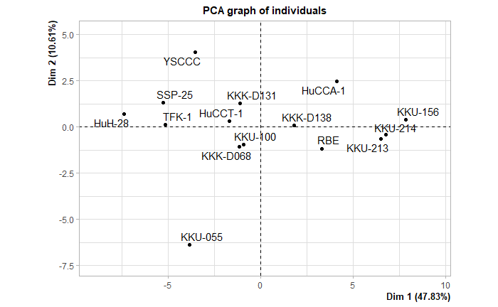

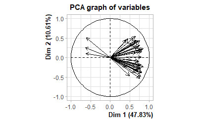

```r
# Draw barplot as right, row annotation
# use Cos2 (contribution to PC components) of variable (genes)
dset.cca <- dat.hc %>% subset(rownames(.) %in% to)
# compare to prcomp()
require(FactoMineR)
pp <- PCA(dset.cca,scale.unit = TRUE,graph = TRUE)
```

```r
ppcos2 <- pp$var$cos2 %>% as.data.frame()

ppcos2 <- tibble::rownames_to_column(ppcos2, var = 'Gene')

ppcos2$Dim.1.2 <- rowSums(ppcos2[,2:3])

ppcos2$Dim.1.cor <- pp$var$cor[,1]

ppcos2$group <- ifelse(ppcos2$Dim.1.cor < 0, 'PC2','PC1') %>% as.factor()

ppcos2 <- ppcos2 %>% arrange(group,-Dim.1.2)

ppcos2$Gene <- factor(ppcos2$Gene, levels = ppcos2$Gene)
```

```r
# create data for the row annotation based on coefficient values
mybar <- ppcos2
# modify Dim.1.2 sign
mybar$Dim.1.2 <- ifelse(mybar$Dim.1.cor < 0, -mybar$Dim.1.2, mybar$Dim.1.2)

mybar <- mybar %>% dplyr::select(Gene,Dim.1.2)

mybar <- tibble::column_to_rownames(mybar, var = 'Gene')
```

Download coefficient scores

```r
setwd('C:/Users/patipark/Dropbox/CCA/module4_data')
```

```
The working directory was changed to C:/Users/patipark/Dropbox/CCA/module4_data inside a notebook chunk. The working directory will be reset when the chunk is finished running. Use the knitr root.dir option in the setup chunk to change the working directory for notebook chunks.
```

```r
# write.csv(ridge.coef, file = 'Coeff_RidgeRegression_20200227.csv',row.names = FALSE)
mycoef <- read.csv('CoefficientValues_20200326.csv',header = TRUE,stringsAsFactors = FALSE)
```

Create row annotation for expr matrix of CCA patients + cell lines. It contains 2 information, Cos2 and Coef values, that would be calculated at later section. But it was placed at this point because it’s required for figure drawing.

```r
# add coefficient
mybar$Coef <- mycoef$Coef[match(rownames(mybar),mycoef$Gene)]
# set barplot as a row annotation
ha2.row <- ComplexHeatmap::rowAnnotation(Cos2 = anno_barplot(mybar$Dim.1.2, baseline = 0),
                                         Coef = anno_barplot(mybar$Coef, baseline = 0))
```

Draw a heatmap. Genes were arranged by Cos2 values

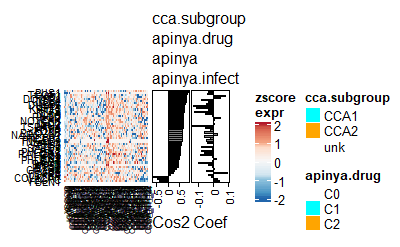

```r
# Plot heatmap
Fig6.Cos2 <- ComplexHeatmap::Heatmap(as.matrix(myMatrix2), # my.dt.sorted
                  # column_km = 2,
                  # split = clusters,
                  # gap = unit(2,'mm'),
                  # row_gap = gap,
                  row_names_side = 'left',
                  # column_km = 2,
                  cluster_rows = FALSE,
                  clustering_distance_rows = 'euclidean',
                  clustering_method_rows = 'complete',
                  show_row_dend = FALSE,
                  row_dend_width = unit(5,'mm'),
                  show_row_names = TRUE,
                  cluster_columns = FALSE,
                  clustering_distance_columns = 'euclidean',
                  clustering_method_columns = 'ward.D2',
                  show_column_dend = FALSE,
                  show_column_names = TRUE,
                  column_dend_height = unit(5,'mm'),
                  column_names_gp = gpar(fontsize = 6, family = 'Arial'),
                  row_names_gp = gpar(fontsize = 8, family = 'Arial'),
                  top_annotation = ha2.col,
                  right_annotation = ha2.row,
                  # bottom_annotation = ha.col,
                  col = circlize::colorRamp2(c(-2,-1.75,-1,-0.75,0,0.75,1,1.75,2), mycolors),
                  # heatmap_legend_param = list(
                  #   color_bar = 'discrete',
                  #   direction = 'horizontal',nrow = 1),
                  # column_title = paste0('Classified by \n',gsub('_S.R','',my.drug),' GR50'),
                  name = 'zscore\nexpr' # legend title
)

Fig6.Cos2
```

Rearrange genes by Ridge regression coefficient values.

```r
# modify coefficient table
mybarCoef <- mybar %>% tibble::rownames_to_column(., var = 'Gene')

# rearrange gene by Cos2 and Coefficient values
mybarCoef <- mybarCoef %>% mutate(Group = ifelse(Dim.1.2 < 0, -1,1)) %>%
                                      group_by(Group) %>%
                                      arrange(Coef)

mybarC <- mybarCoef %>% group_by(Group) %>% arrange(-Group,Coef)

# rearrange rows in gene expression data
myMatrix2.Coef <- myMatrix2[mybarCoef$Gene,]

# rearrange columns by euclidean distance from ind.my.eudis
myMatrix2.Coef <- myMatrix2[,cell.my.eudis$ID]

# define row annotation
ha2Coef.row <- ComplexHeatmap::rowAnnotation( #Cos2 = anno_barplot(mybar5B.45$Dim.1.2, baseline = 0),
                                         Coef = anno_barplot(mybarC$Coef, baseline = 0))
```

Draw a heatmap in which genes are arranged by Coef values.

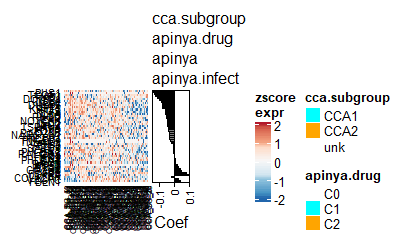

```r
# Plot heatmap
Fig6A.Coef <- ComplexHeatmap::Heatmap(as.matrix(myMatrix2.Coef), # my.dt.sorted
                  # column_km = 2,
                  # split = clusters,
                  # gap = unit(2,'mm'),
                  # row_gap = gap,
                  row_names_side = 'left',
                  cluster_rows = FALSE,
                  clustering_distance_rows = 'euclidean',
                  clustering_method_rows = 'ward.D2',
                  show_row_dend = FALSE,
                  row_dend_width = unit(5,'mm'),
                  show_row_names = TRUE,
                  cluster_columns = FALSE,
                  clustering_distance_columns = 'euclidean',
                  clustering_method_columns = 'ward.D2',
                  show_column_dend = TRUE,
                  show_column_names = TRUE,
                  column_dend_reorder = TRUE,
                  column_dend_height = unit(5,'mm'),
                  column_names_gp = gpar(fontsize = 6, family = 'Arial'),
                  row_names_gp = gpar(fontsize = 8, family = 'Arial'),
                  top_annotation = ha2.col,
                  right_annotation = ha2Coef.row,
                  # bottom_annotation = ha.col,
                  col = circlize::colorRamp2(c(-2,-1.75,-1,-0.75,0,0.75,1,1.75,2), mycolors),
                  # heatmap_legend_param = list(
                  #   color_bar = 'discrete',
                  #   direction = 'horizontal',nrow = 1),
                  # column_title = paste0('Classified by \n',gsub('_S.R','',my.drug),' GR50'),
                  name = 'zscore\nexpr' # legend title
)

Fig6A.Coef
```

Save figure 7A

```r
# Save Jusakul-CCA heatmap fig5B
setwd('C:/Users/patipark/Dropbox/CCA/module4_results')
pdf(paste0('Fig7A_45Genes_EuclideanByCells_20200925.pdf'),
    height = 7,
    width = 15)
draw(Fig6A.Coef,
     height = unit(5,'in'),
     width = unit(14,'in')
     )
dev.off()
```

Rearrange column using seriate function

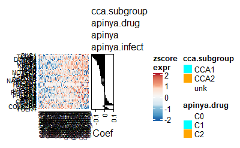

```r
require(seriation)
m <- as.matrix(myMatrix2.Coef)
# seriation require non-negative matrix
mm <- m - min(m)

o <- seriate(mm, method = "BEA_TSP")

# for row
o1 <- seriate(dist(m), method = "R2E")
# for column
o2 <- seriate(dist(t(m)), method = "ARSA")

# extract column order
new.col.order <- colnames(m)[get_order(o2)]
# Rearrange column annotations
### Column annotation
# tally the hallmark ID and genes
# get sample IDs
df.col <- data.frame('ID' = colnames(datin))
# add data set names
df.col$dataset <- ref.col$dataset[match(df.col$ID,ref.col$ID)]
# add drug subgroup
df.col$subgroup <- ref.col$subgroup[match(df.col$ID,ref.col$ID)]
# add molecular subgroup annotation
df.col$apinya.subgroup <- ref.col$apinya.subgroup[match(df.col$ID,ref.col$ID)]
# add 0 to samples with molecular subgroup
df.col$apinya.subgroup[is.na(df.col$apinya.subgroup)] <- 0

# add color for data set subgroup
df.col$ds.color <- ifelse(df.col$dataset == 'cca', 'red',
                           ifelse(df.col$dataset == 'tiger', 'blue','green'))
# add color drug response subgroup
df.col$sg.color <- ifelse(df.col$subgroup == 'CCA1','cyan',
                          ifelse(df.col$subgroup == 'CCA2', 'orange','gray50'))
# add molecular subgroup
df.col$apsg.color <- ifelse(df.col$apinya.subgroup == 1,'C1',
                            ifelse(df.col$apinya.subgroup == 2,'C2',
                                   ifelse(df.col$apinya.subgroup == 3,'C3',
                                          ifelse(df.col$apinya.subgroup == 4,'C4','N'))))
# rearrange ID column to rownames
df.col <- tibble::column_to_rownames(df.col, var = 'ID')

# rearrange rows of ID
# df.col <- df.col[ordertab$ID,]

# rearrange rows of ID by euclidean distance
df.col <- df.col[new.col.order,] #df.col[cell.my.eudis$ID,]

# add predicted drug response subgroup from unsupervised hierarchical clustering
# dist = manhattan, cluster = ward.D2
df.col$pred.CCA <- ordertab$Cluster[match(rownames(df.col),ordertab$ID)]
# assign correct drug response subgroup to CCA cell lines
df.col$pred.CCA <- ifelse(rownames(df.col) %in% to[1:6], 1,
                          ifelse(rownames(df.col) %in% to[7:15], 2, df.col$pred.CCA))
# convert from numbers to code names
df.col$pred.CCA2 <- ifelse(df.col$pred.CCA == 1,'C1',
                           ifelse(df.col$pred.CCA == 2,'C2','C0'))
df.col$pred.CCA2[is.na(df.col$pred.CCA2)] <- 'C0'
# convert from numbers to code names
df.col$pred.CCA <- ifelse(df.col$pred.CCA == 1, 'CCA1','CCA2')
# convert data set to code names
df.col$pred.CCA2 <- ifelse(df.col$dataset == 'cca','C0',df.col$pred.CCA2)

# separate data set for column annotation
# dataset
ds.apinya <- df.col$apsg.color
names(ds.apinya) <- rownames(df.col)

ds.apinya.drug <- df.col$pred.CCA2
names(ds.apinya.drug) <- rownames(df.col)

# ds.apinya <- ifelse(df.col$dataset == 'apinya','Y','N')
# names(ds.apinya) <- rownames(df.col)
ds.cca <- ifelse(df.col$dataset == 'cca','Y','N')
names(ds.cca) <- rownames(df.col)
ds.ccasg <- df.col$subgroup
names(ds.ccasg) <- rownames(df.col)

# add liver-fluke status
df.col$infect <- clinical.data$Fluke.Infection[match(rownames(df.col),clinical.data$ID)]
df.col$infect[is.na(df.col$infect)] <- 'None'
ds.infect <- df.col$infect
names(ds.infect) <- rownames(df.col)

# define color
require(circlize)
mycolors <- rev(c('#b2182b','#d6604d','#f4a582','#fddbc7','#f7f7f7','#d1e5f0','#92c5de','#4393c3','#2166ac'))

# # order of columns annotation also depend of the order of matched pairs
# cca.subgroup <- ds.ccasg[match(ordertab$ID,names(ds.ccasg))]
# apinya.drug <- ds.apinya.drug[match(ordertab$ID,names(ds.apinya.drug))]
# apinya <- ds.apinya[match(ordertab$ID,names(ds.apinya))]
# apinya.infect <- ds.infect[match(ordertab$ID,names(ds.infect))]

# use ordering from euclidean distance
cca.subgroup <- ds.ccasg[match(new.col.order,names(ds.ccasg))]
apinya.drug <- ds.apinya.drug[match(new.col.order,names(ds.apinya.drug))]
apinya <- ds.apinya[match(new.col.order,names(ds.apinya))]
apinya.infect <- ds.infect[match(new.col.order,names(ds.infect))]

# Prepare column annotation.
# column annotation
ha2.col <- ComplexHeatmap::HeatmapAnnotation(cca.subgroup = cca.subgroup,
                             apinya.drug = apinya.drug,
                             apinya = apinya,
                             apinya.infect = apinya.infect,
                             col = list(apinya = c('C1' = 'dodgerblue','C2' = 'lightgoldenrod',
                                                   'C3' = 'olivedrab2','C4' = 'firebrick2',
                                                   'N' = 'white'),
                                        apinya.drug = c('C1' = 'cyan','C2' = 'orange','C0' = 'white'),
                                        apinya.infect = c('Fluke-Pos' = 'firebrick',
                                                          'Fluke-Neg' = 'lightpink',
                                                          'None' = 'white'),
                                        cca.subgroup = c('CCA1'='cyan','CCA2'='orange','unk'='white')

                                        ),
                             gp = gpar(col = 'white'),
                             annotation_height = unit.c(unit(0.5,'cm'),
                                                        unit(1,'cm'),
                                                        unit(1,'cm'),
                                                        unit(1,'cm'),
                                                        unit(2,'cm'))# add border color

)

m.mat <- m[,new.col.order]

# Draw a heatmap in which genes are arranged by Coef values.
# Plot heatmap
Fig6A.Coef.ARSA <- ComplexHeatmap::Heatmap(m.mat, # my.dt.sorted
                  # column_km = 2,
                  # split = clusters,
                  # gap = unit(2,'mm'),
                  # row_gap = gap,
                  row_names_side = 'left',
                  cluster_rows = FALSE,
                  clustering_distance_rows = 'euclidean',
                  clustering_method_rows = 'ward.D2',
                  show_row_dend = FALSE,
                  row_dend_width = unit(5,'mm'),
                  show_row_names = TRUE,
                  cluster_columns = FALSE,
                  clustering_distance_columns = 'euclidean',
                  clustering_method_columns = 'ward.D2',
                  show_column_dend = TRUE,
                  show_column_names = TRUE,
                  column_dend_reorder = TRUE,
                  column_dend_height = unit(5,'mm'),
                  column_names_gp = gpar(fontsize = 6, family = 'Arial'),
                  row_names_gp = gpar(fontsize = 8, family = 'Arial'),
                  top_annotation = ha2.col,
                  right_annotation = ha2Coef.row,
                  # bottom_annotation = ha.col,
                  col = circlize::colorRamp2(c(-2,-1.75,-1,-0.75,0,0.75,1,1.75,2), mycolors),
                  # heatmap_legend_param = list(
                  #   color_bar = 'discrete',
                  #   direction = 'horizontal',nrow = 1),
                  # column_title = paste0('Classified by \n',gsub('_S.R','',my.drug),' GR50'),
                  name = 'zscore\nexpr' # legend title
)

Fig6A.Coef.ARSA
```

Given new column order

```r
new.clusters <- clusters

new.clusters <- ifelse(names(new.clusters) %in% new.col.order[1:57],2,1)

names(new.clusters) <- names(clusters)

clusters <- new.clusters
```

Draw a heatmp whose few genes were removed and rearranged by ridge coefficient values with separation between positve NES and negative NES gene sets.

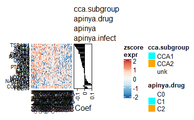

```r
# remove TP53, AREG, TCOF1, TNFAIP2 from gene expression matrix
myMatrix2.Coef4 <- myMatrix2.Coef %>% subset(!rownames(.) %in% c('TP53','AREG','TCOF1','TNFAIP2'))

# remove the above genes from row annotation table
mybarCoef4 <- mybarCoef %>% subset(!Gene %in% c('TP53','AREG','TCOF1','TNFAIP2'))

# rearrange by Coefficient values
mybarCoef5 <- mybarCoef4 %>% group_by(Group) %>% arrange(-Group,Coef)

# define new row annotation
ha2Coef5.row <- ComplexHeatmap::rowAnnotation( #Cos2 = anno_barplot(mybarCoef5$Dim.1.2, baseline = 0),
                                         Coef = anno_barplot(mybarCoef5$Coef, baseline = 0))
# rearrange genes in the matrix
myMatrix2.Coef5 <- myMatrix2.Coef4[mybarCoef5$Gene,]

# plot a heatmap
Fig6A.Coef5 <- ComplexHeatmap::Heatmap(as.matrix(myMatrix2.Coef5), # my.dt.sorted
                  # column_km = 2,
                  # split = clusters,
                  # gap = unit(2,'mm'),
                  # row_gap = gap,
                  row_names_side = 'left',
                  # column_km = 2,
                  cluster_rows = FALSE,
                  clustering_distance_rows = 'euclidean',
                  clustering_method_rows = 'complete',
                  show_row_dend = FALSE,
                  row_dend_width = unit(5,'mm'),
                  show_row_names = TRUE,
                  cluster_columns = FALSE,
                  clustering_distance_columns = 'euclidean',
                  clustering_method_columns = 'ward.D2',
                  show_column_dend = TRUE,
                  show_column_names = TRUE,
                  column_dend_height = unit(5,'mm'),
                  column_names_gp = gpar(fontsize = 6, family = 'Arial'),
                  row_names_gp = gpar(fontsize = 8, family = 'Arial'),
                  top_annotation = ha2.col,
                  right_annotation = ha2Coef5.row,
                  # bottom_annotation = ha.col,
                  col = circlize::colorRamp2(c(-2,-1.75,-1,-0.75,0,0.75,1,1.75,2), mycolors),
                  # heatmap_legend_param = list(
                  #   color_bar = 'discrete',
                  #   direction = 'horizontal',nrow = 1),
                  # column_title = paste0('Classified by \n',gsub('_S.R','',my.drug),' GR50'),
                  name = 'zscore\nexpr' # legend title
)

Fig6A.Coef5
```

Save Jusakul-CCA heatmap Figure 6A.Coef5

```r
# setwd('C:/Users/patipark/Dropbox/CCA project/CCA RNA-seq/NewGeneSet_Module_InitialAnalysis/Figure_5A_files')
# pdf(paste0('Fig6ACoef5_CombinedDatasets_Heatmap_JusakulCCA_20200326.pdf'),
#     height = 7,
#     width = 15)
# draw(Fig6A.Coef5,
#      height = unit(5,'in'),
#      width = unit(14,'in')
#      )
# dev.off()
```

However, ridge cofficient values were actually calculated at later steps.

From this point, we were going to find ridge cofficient values. Initially, we succesfully classify patients and cell lines into two groups using unsupervised clustering. (Euclidean distant and Ward.D2 method.). To make clustering consistency, we aimed to find numerical values for each biomarkers.

However, we needed to make sure that the two groups have significant survival rate.

Based on unsupervised clustering above, examine CCA patient overall survival

```r
# Prepare clinical data
# y_auc <- known.class
patient.list <- colnames(myMatrix2.Coef5) #colnames(myFig6ACoef5)

clinical.data <- annotation.apinya %>% subset(Sample.ID %in% patient.list)
# select columns
clinical.data <- clinical.data[,c(1,2,3,4,6,11,12,13,14,22)]
# rename columns
colnames(clinical.data) <- c('ID','Fluke.Infection','Country','Sex','Anatomical.subtype','TNM.Stage','Stage','Vital.state','Survival.days','Cluster')

# add predicted drug response subgroup
clinical.data$Drug.subgroup <- clusters[match(clinical.data$ID,names(clusters))]

# turn to numeric
# vital.state: 1 = death, 0 = survive
clinical.data$Vital.state <- as.numeric(clinical.data$Vital.state)
```

```
NAs introduced by coercion
```

```r
clinical.data$Survival.days <- as.numeric(clinical.data$Survival.days)
```

```
NAs introduced by coercion
```

```r
clinical.data$Cluster <- as.numeric(clinical.data$Cluster)

# clinical data 3 year survival
clinical.data$Vital.state3 <- ifelse(clinical.data$Survival.days > 1095, 0, 1)

clinical.data$Vital.state1 <- ifelse(clinical.data$Survival.days > 366, 0, 1)

clinical.data$Vital.state2 <- ifelse(clinical.data$Survival.days > 731, 0, 1)

# separate T from TNM stage
clinical.data$TNM <- substr(clinical.data$TNM.Stage,1,2)
clinical.data$TNM <- ifelse(clinical.data$TNM == 'Ti', 'T0',
                            ifelse(clinical.data$TNM == 'N/', NA,
                                   ifelse(clinical.data$TNM == 'Tx', NA, clinical.data$TNM)))
```

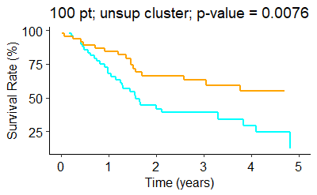

```r
# calculate survival rate
require(survival)
require(survminer)

km.by.drug <- survival::survfit(Surv(Survival.days, Vital.state) ~ Drug.subgroup, data = clinical.data, conf.type = 'log-log')

# calculate OS rate
km.drug.group <- coxph(Surv(Survival.days, Vital.state) ~ Drug.subgroup,
                   data = clinical.data)

# prepare summary output
sum.drug <- surv_summary(km.by.drug, data = clinical.data) %>% as.data.frame()

# conversion function
convert <- function(input){
  # convert time in days to years
  # call function decimal
  specify_decimal <- function(x, k) trimws(format(round(x, k), nsmall = k))
  input$time.year <- specify_decimal(input$time / 365.25, k = 2) %>% as.numeric()
  # convert surv to 100%
  input$surv <- input$surv * 100

  # add factor levels
  input$Drug.subgroup <- ifelse(input$Drug.subgroup == 1,'CCA1','CCA2')
  input$Drug.subgroup <- factor(input$Drug.subgroup, levels = c('CCA1','CCA2'))

  mean.survival <- input %>% group_by(Drug.subgroup) %>% summarise(mean.survival = mean(time.year))

  input$lty <- ifelse(input$Drug.subgroup == 'CCA1','CCA1','CCA2')

  return(input)
}

sum.drug <- convert(sum.drug)

OS100pt <- ggplot() +
  geom_step(data = sum.drug,
            aes(x = time.year,
                y = surv,
                group = Drug.subgroup,
                color = Drug.subgroup,
                alpha = lty),
            size = 1) +
  scale_color_manual(values = c('CCA1' = 'cyan', 'CCA2' = 'orange')) +
  scale_shape_manual(values = c('CCA1' = 16, 'CCA2' = 16)) +
  scale_alpha_manual(values = c('drug' = 1,'molec' = 1)) +
  scale_size_manual(values = c('drug' = 1,'molec' = 1)) +
  scale_x_continuous(breaks = seq(0,8,1), limits = c(0,5)) +
  theme_pubr() +
  theme(
    # text = element_text(family = 'Arial', size = 10),
    # axis.text = element_text(family = 'Arial', size = 8),
    # axis.title = element_text(size = 10),
    legend.position = 'none'
  ) +
  # facet_grid(lty ~ .) +
  labs(x = 'Time (years)',
       y = 'Survival Rate (%)',
       title = paste0('100 pt; unsup cluster; p-value = ',round(summary(km.drug.group)$coefficients[5],4)))

# use all CCA patients drug subtype 1
OS100pt
```

```r
setwd('C:/Users/patipark/Dropbox/CCA project/CCA RNA-seq/NewGeneSet_Module_InitialAnalysis/Figure_5A_files')
ggsave(OS100pt,
       filename = 'Figure_OS_100pt_cluster_20200326.pdf',
       height = 9,
       width = 12,
       units = 'cm',
       device = cairo_pdf)
dev.off()
```

```r
pval.surv <- surv_pvalue(km.by.drug, combine = FALSE)

pval.surv
```

| variable | pval | method | pval.txt |
| --- | --- | --- | --- |
| Drug.subgroup | 0.00618004 | Log-rank | p = 0.0062 |

Asian country patients

```r
# subset data for Asian patients only
clinical.dataAsia <- clinical.data %>% subset(Country %in% c('Singapore','Thailand','Korea'))

# by group
Asfit.group <- coxph(Surv(Survival.days, Vital.state) ~ Drug.subgroup,
                   data = clinical.dataAsia)

summary(Asfit.group)
```

```
Call:
coxph(formula = Surv(Survival.days, Vital.state) ~ Drug.subgroup,
    data = clinical.dataAsia)

  n= 66, number of events= 32
   (1 observation deleted due to missingness)

                 coef exp(coef) se(coef)      z Pr(>|z|)
Drug.subgroup -0.5877    0.5556   0.3664 -1.604    0.109

              exp(coef) exp(-coef) lower .95 upper .95
Drug.subgroup    0.5556        1.8     0.271     1.139

Concordance= 0.593  (se = 0.044 )
Likelihood ratio test= 2.67  on 1 df,   p=0.1
Wald test            = 2.57  on 1 df,   p=0.1
Score (logrank) test = 2.65  on 1 df,   p=0.1
```

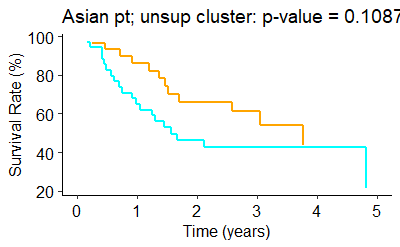

```r
# draw survival plot of Asian patients
Asian.drug <- survival::survfit(Surv(Survival.days, Vital.state) ~ Drug.subgroup,
                                data = clinical.dataAsia, conf.type = 'log-log')

sum.Asian.drug <- surv_summary(Asian.drug, data = clinical.dataAsia) %>% as.data.frame()

sum.AsDrug <- convert(sum.Asian.drug)

# calculate OS rate
As.drug.group <- coxph(Surv(Survival.days, Vital.state) ~ Drug.subgroup,
                   data = clinical.dataAsia)

OS100pt.Asian <- ggplot() +
  geom_step(data = sum.AsDrug,
            aes(x = time.year,
                y = surv,
                group = Drug.subgroup,
                color = Drug.subgroup,
                alpha = lty),
            size = 1) +
  scale_color_manual(values = c('CCA1' = 'cyan', 'CCA2' = 'orange')) +
  scale_shape_manual(values = c('CCA1' = 16, 'CCA2' = 16)) +
  scale_alpha_manual(values = c('drug' = 1,'molec' = 1)) +
  scale_size_manual(values = c('drug' = 1,'molec' = 1)) +
  scale_x_continuous(breaks = seq(0,8,1), limits = c(0,5)) +
  theme_pubr() +
  theme(
    # text = element_text(family = 'Arial', size = 10),
    # axis.text = element_text(family = 'Arial', size = 8),
    # axis.title = element_text(size = 10),
    legend.position = 'none'
  ) +
  # facet_grid(lty ~ .) +
  labs(x = 'Time (years)',
       y = 'Survival Rate (%)',
       title = paste0('Asian pt; unsup cluster: p-value = ',round(summary(As.drug.group)$coefficients[5],4)))

# use all CCA patients drug subtype 1
OS100pt.Asian
```

```r
# setwd('C:/Users/patipark/Dropbox/CCA project/CCA RNA-seq/NewGeneSet_Module_InitialAnalysis/Figure_5A_files')
# ggsave(OS100pt.Asian,
#        filename = 'Figure_OS_Asianpt_cluster_20200326.pdf',
#        height = 9,
#        width = 12,
#        units = 'cm',
#        device = cairo_pdf)
# dev.off()
```

```r
# subset data
clinical.dataEU <- clinical.data %>% subset(!Country %in% c('Singapore','Thailand','Korea'))

# by group
EUfit.group <- coxph(Surv(Survival.days, Vital.state) ~ Drug.subgroup,
                   data = clinical.dataEU)

summary(EUfit.group)
```

```
Call:
coxph(formula = Surv(Survival.days, Vital.state) ~ Drug.subgroup,
    data = clinical.dataEU)

  n= 31, number of events= 17
   (2 observations deleted due to missingness)

                 coef exp(coef) se(coef)      z Pr(>|z|)
Drug.subgroup -1.3980    0.2471   0.5581 -2.505   0.0122 *
---
Signif. codes:  0 ‘***’ 0.001 ‘**’ 0.01 ‘*’ 0.05 ‘.’ 0.1 ‘ ’ 1

              exp(coef) exp(-coef) lower .95 upper .95
Drug.subgroup    0.2471      4.047   0.08276    0.7377

Concordance= 0.604  (se = 0.075 )
Likelihood ratio test= 6.95  on 1 df,   p=0.008
Wald test            = 6.28  on 1 df,   p=0.01
Score (logrank) test = 7.19  on 1 df,   p=0.007
```

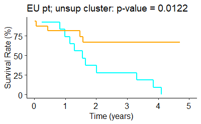

```r
# Draw survival plot for non-Asian group
EU.drug <- survival::survfit(Surv(Survival.days, Vital.state) ~ Drug.subgroup,
                                data = clinical.dataEU, conf.type = 'log-log')

sum.EU.drug <- surv_summary(EU.drug, data = clinical.dataEU) %>% as.data.frame()

sum.EUDrug <- convert(sum.EU.drug)

OS100pt.EU <- ggplot() +
  geom_step(data = sum.EUDrug,
            aes(x = time.year,
                y = surv,
                group = Drug.subgroup,
                color = Drug.subgroup,
                alpha = lty),
            size = 1) +
  scale_color_manual(values = c('CCA1' = 'cyan', 'CCA2' = 'orange')) +
  scale_shape_manual(values = c('CCA1' = 16, 'CCA2' = 16)) +
  scale_alpha_manual(values = c('drug' = 1,'molec' = 1)) +
  scale_size_manual(values = c('drug' = 1,'molec' = 1)) +
  scale_x_continuous(breaks = seq(0,8,1), limits = c(0,5)) +
  theme_pubr() +
  theme(
    # text = element_text(family = 'Arial', size = 10),
    # axis.text = element_text(family = 'Arial', size = 8),
    # axis.title = element_text(size = 10),
    legend.position = 'none'
  ) +
  # facet_grid(lty ~ .) +
  labs(x = 'Time (years)',
       y = 'Survival Rate (%)',
       title = paste0('EU pt; unsup cluster: p-value = ',round(summary(EUfit.group)$coefficients[5],4)))


# use all CCA patients drug subtype 1
OS100pt.EU
```

```r
# setwd('C:/Users/patipark/Dropbox/CCA project/CCA RNA-seq/NewGeneSet_Module_InitialAnalysis/Figure_5A_files')
# ggsave(OS100pt.EU,
#        filename = 'Figure_OS_EUpt_cluster_20200326.pdf',
#        height = 9,
#        width = 12,
#        units = 'cm',
#        device = cairo_pdf)
# dev.off()
```

```r
# subset data for Thailand or OV-infected patients only
clinical.dataTH <- clinical.data %>% subset(Country %in% c('Thailand'))

# by group
THfit.group <- coxph(Surv(Survival.days, Vital.state) ~ Drug.subgroup,
                   data = clinical.dataTH)

summary(THfit.group)
```

```
Call:
coxph(formula = Surv(Survival.days, Vital.state) ~ Drug.subgroup,
    data = clinical.dataTH)

  n= 36, number of events= 26
   (1 observation deleted due to missingness)

                 coef exp(coef) se(coef)      z Pr(>|z|)
Drug.subgroup -0.3679    0.6922   0.4291 -0.857    0.391

              exp(coef) exp(-coef) lower .95 upper .95
Drug.subgroup    0.6922      1.445    0.2985     1.605

Concordance= 0.565  (se = 0.044 )
Likelihood ratio test= 0.77  on 1 df,   p=0.4
Wald test            = 0.74  on 1 df,   p=0.4
Score (logrank) test = 0.74  on 1 df,   p=0.4
```

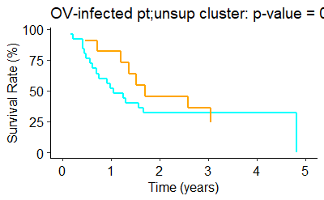

```r
# Draw survival plot for Thai or OV-infected group
TH.drug <- survival::survfit(Surv(Survival.days, Vital.state) ~ Drug.subgroup,
                                data = clinical.dataTH, conf.type = 'log-log')

sum.TH.drug <- surv_summary(TH.drug, data = clinical.dataTH) %>% as.data.frame()

sum.THDrug <- convert(sum.TH.drug)

OS100pt.TH <- ggplot() +
  geom_step(data = sum.THDrug,
            aes(x = time.year,
                y = surv,
                group = Drug.subgroup,
                color = Drug.subgroup,
                alpha = lty),
            size = 1) +
  scale_color_manual(values = c('CCA1' = 'cyan', 'CCA2' = 'orange')) +
  scale_shape_manual(values = c('CCA1' = 16, 'CCA2' = 16)) +
  scale_alpha_manual(values = c('drug' = 1,'molec' = 1)) +
  scale_size_manual(values = c('drug' = 1,'molec' = 1)) +
  scale_x_continuous(breaks = seq(0,8,1), limits = c(0,5)) +
  theme_pubr() +
  theme(
    # text = element_text(family = 'Arial', size = 10),
    # axis.text = element_text(family = 'Arial', size = 8),
    # axis.title = element_text(size = 10),
    legend.position = 'none'
  ) +
  # facet_grid(lty ~ .) +
  labs(x = 'Time (years)',
       y = 'Survival Rate (%)',
        title = paste0('OV-infected pt;unsup cluster: p-value = ',round(summary(THfit.group)$coefficients[5],4)))

# use all CCA patients drug subtype 1
OS100pt.TH
```

```r
# setwd('C:/Users/patipark/Dropbox/CCA project/CCA RNA-seq/NewGeneSet_Module_InitialAnalysis/Figure_5A_files')
# ggsave(OS100pt.TH,
#        filename = 'Figure_OS_OVpt_cluster_20200326.pdf',
#        height = 9,
#        width = 12,
#        units = 'cm',
#        device = cairo_pdf)
# dev.off()
```

Table S5 Cofficient values Find coefficient for each parameter (gene) that can separate CCA patients into groups with significant OS.

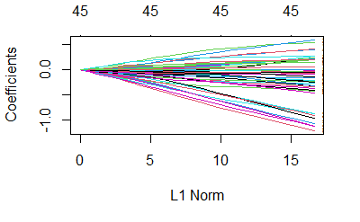

```r
# 1. glmnet
# build model-predict class
require(glmnet)
# create X input from gene expression from Figure5B heatmap
# samples include CCA cell lines (n = 15) and patients (n = 100)
X.glm <- t(myMatrix2.Coef) #t(myFig6ACoef)
# create Y input
Y.glm <- data.frame('ID' = rownames(X.glm))
# assign drug response subgroup to samples based on the hierarchical clustering above
Y.glm$drug.group <- ordertab$Cluster[match(Y.glm$ID,ordertab$ID)]
# make correction on CCA cell lines
Y.glm$drug.group <- ifelse(Y.glm$ID %in% to[1:6], 1,
                           ifelse(Y.glm$ID %in% to[7:15], 2, Y.glm$drug.group))

lambda <- 10^seq(10, -2, length = 100)

set.seed(100)
fit.glm <- glmnet::glmnet(x = as.matrix(X.glm),
                          y = Y.glm$drug.group,
                          family = 'binomial',
                          alpha = 0, # 1 = LASSO, 0 = ridge regression
                          lambda = lambda
                          )

plot(fit.glm, label = TRUE)
```

```r
# setwd('C:/Users/patipark/Dropbox/CCA project/CCA RNA-seq/NewGeneSet_Module_InitialAnalysis/Figure_5A_files')
# pdf(paste0('Figure_GLM_20200326.pdf'),
#     height = 5,
#     width = 7)
# plot(fit.glm, label = TRUE)
# dev.off()
```

Run Cross validation

```r
set.seed(100)
cvfit.glm <- glmnet::cv.glmnet(x = as.matrix(X.glm),
                               y = Y.glm$drug.group,
                               alpha = 0,
                               lambda = lambda)
```

```r
cvfit.glm$lambda.min
```

```r
# find lambda with 1SE
cvfit.glm$lambda.1se
```

```r
# find
plot(cvfit.glm)
```

```r
# setwd('C:/Users/patipark/Dropbox/CCA project/CCA RNA-seq/NewGeneSet_Module_InitialAnalysis/Figure_5A_files')
# pdf(paste0('Figure_MSE_20200326.pdf'),
#     height = 5,
#     width = 7)
# plot(cvfit.glm)
# dev.off()
```

```r
# lambda from 1SE
mylambda <- 1.149757
set.seed(100)
fit2.glm <- glmnet::glmnet(x = as.matrix(X.glm),
                          y = Y.glm$drug.group,
                          family = 'binomial',
                          alpha = 0, # 0 = ridge regression, 1 = LASSO
                          lambda = mylambda)
coef(fit2.glm)
```

Use to glm model to predict patient data

```r
# subset gene expression data from ~30% of the samples from myFig6ACoef
newX <- t(myMatrix2.Coef) #t(myFig6ACoef)
# random sampling
# rndsam <- sample(rownames(newX), size = ceiling(nrow(newX)*0.3))
# use CCA cell lines as testing set
rndsam <- rownames(newX)[c(!rownames(newX) %in% to)]
# subset data using randomly samples
newX <- newX[rndsam,]

y_predicted <- glmnet::predict.glmnet(object = fit2.glm,
                                      newx = newX,
                                      s = cvfit.glm$lambda.1se,
                                      type = 'class')
# convert response to drug subclass
y_predicted <- as.data.frame(y_predicted)
# response < 0; drug class 1, response > 0; drug class 2
y_predicted$pred <- ifelse(y_predicted$`1` > 0, 2, 1)
# assign reference
y_predicted$ref <- Y.glm$drug.group[match(rownames(y_predicted),Y.glm$ID)]

# use caret to obtain prediction accuracy
# add factor level to the data
y_predicted$ref <- as.factor(y_predicted$ref)
y_predicted$pred <- as.factor(y_predicted$pred)

conMat.pt <- caret::confusionMatrix(data = y_predicted$pred,
                       reference = y_predicted$ref,
                       mode = 'prec_recall')

conMat.pt
```

Plot ROC curve to demonstrate performance of prediction parameters

```r
# use caret to build glmnet model of ridge regression
# use lambda from the cross-validated glm ridge regression model cvfit.glm$lambda.1se
Y.glm$drug.group <- as.factor(Y.glm$drug.group)
# x input is gene expression from CCA cell lines and patients
# similar to the input used in glmnet package
# create training model
ridge_caret <- caret::train(x = as.matrix(X.glm),
                            y = Y.glm$drug.group,
                            method = 'glmnet',
                            lambda = mylambda,
                            summaryFunction = 'twoClassSummary',
                            tuneGrid = expand.grid(alpha = 0, lambda = 0))

ridge_caret
```

```r
# predict class of CCA patients
pred.prob <- caret::predict.train(object = ridge_caret,
                                  newdata = newX,
                                  type = 'prob')

# add ID to rownames of the prediction results
rownames(pred.prob) <- rownames(newX)

# identify class from probability
pred.prob$pred <- ifelse(pred.prob$`1` > pred.prob$`2`, 1, 2)

# add reference class
pred.prob$ref <- ordertab$Cluster[match(rownames(pred.prob),ordertab$ID)]

# get ROC
result.roc <- pROC::roc(pred.prob$pred, pred.prob$ref) # Draw ROC curve.

pROC100 <- pROC::ggroc(result.roc,
      alpha = 0.5,
      colour = 'black',
      linetype = 1,
      size = 1) +
  theme_minimal() +
  geom_abline(intercept = c(1),
              color = 'gray50',
              lty = 2) +
  labs(title = paste0('100 pt; unsup vs. sup; AUC = ',round(result.roc$auc,3)))

pROC100
```

```r
# setwd('C:/Users/patipark/Dropbox/CCA project/CCA RNA-seq/NewGeneSet_Module_InitialAnalysis/Figure_5A_files')
# ggsave(pROC100,
#        filename = 'Figure_pROC100pt_unSupVSSup_20200326.pdf',
#        height = 4,
#        width = 6,
#        units = 'in',
#        device = cairo_pdf)
# dev.off()
```

confusionMatrix’s accuracy = 0.92 AUC = 0.92

```r
# predict class of CCA cell lines
newX.cca <- t(myMatrix2.Coef) #t(myFig6ACoef)

newX.cca <- newX.cca[to,]

pred.prob.cca <- caret::predict.train(object = ridge_caret,
                                  newdata = newX.cca,
                                  type = 'prob')

# add ID to rownames of the prediction results
rownames(pred.prob.cca) <- rownames(newX.cca)

# identify class from probability
pred.prob.cca$pred <- ifelse(pred.prob.cca$`1` > pred.prob.cca$`2`, 1, 2)

# add reference class
pred.prob.cca$ref <- ordertab$Cluster[match(rownames(pred.prob.cca),ordertab$ID)]

# get ROC
result.roc.cca <- pROC::roc(pred.prob.cca$pred, pred.prob.cca$ref) # Draw ROC curve.

pROC15cells <- pROC::ggroc(result.roc.cca,
      alpha = 0.5,
      colour = 'black',
      linetype = 1,
      size = 1) +
  theme_minimal() +
  geom_abline(intercept = c(1),
              color = 'gray50',
              lty = 2) +
  labs(title = paste0('15 cells; unsup vs. sup; AUC = ',round(result.roc.cca$auc,3)))

pROC15cells
```

```r
# setwd('C:/Users/patipark/Dropbox/CCA project/CCA RNA-seq/NewGeneSet_Module_InitialAnalysis/Figure_5A_files')
# ggsave(pROC15cells,
#        filename = 'Figure_pROC15cells_unSupVSSup_20200326.pdf',
#        height = 4,
#        width = 6,
#        units = 'in',
#        device = cairo_pdf)
# dev.off()
```

After evaluating the prediction power of Coef from ridge regression is quite equivalent to the unsupervised method, we continue to use the predicted drug response subgroup using the Coef and assess the prognosis of the biomarkers in CCA patient cohort.

Use coef values to predict drug subclass and evaluate overall survival rate

```r
#test set
demo.X <- t(myMatrix2.Coef5) %>% as.data.frame() #as.matrix(datin.pca)

# subset only CCA cells
demo.X <- demo.X %>% subset(!rownames(.) %in% to)

mybeta <- as.matrix(coef(fit2.glm)) %>% as.data.frame()
```

[output not shown]

```r
setwd('C:/Users/patipark/Dropbox/CCA project/CCA RNA-seq/NewGeneSet_Module_InitialAnalysis/Figure_5A_files')
```

[output not shown]

```r
# write.csv(mybeta, file = 'TableS5_CoefficientValues_20200326.csv',row.names = FALSE)
mybeta <- read.csv('CoefficientValues_20200326.csv', header = TRUE, stringsAsFactors = FALSE)
```

```r
# separate coef rows and intercept row
intercept <- mybeta[1,2]
beta <- mybeta[c(-1),] %>% as.data.frame()

demo.X <- t(myMatrix2.Coef5) %>% as.data.frame() #as.matrix(datin.pca)

# subset only CCA cells
demo.X <- demo.X %>% subset(!rownames(.) %in% to)

require(reshape2)
myX <- tibble::rownames_to_column(as.data.frame(demo.X), var = 'ID')

myX <- melt(myX, id.vars = 'ID', variable.name = 'Gene', value.name = 'expr')

# for each patient
myID <- unique(myX$ID)

pred.table <- lapply(1:length(myID), function(i) {
  # i <- 1
  myIDX <- myX %>% subset(ID %in% myID[i])

  myIDX$Coef <- beta$Coef[match(myIDX$Gene,beta$Gene)]

  myIDX <- myIDX %>% mutate(Pred = (Coef * expr))

  # intercept <- 1.074270587

  pred.val <- intercept + sum(myIDX$Pred)

  out <- data.frame('ID' = myID[i],
                    'response' = pred.val)

  return(out)
})

pred.table <- do.call(rbind,pred.table)

pred.table$pred.coef <- ifelse(pred.table$response >= 0, 2, 1)

y_auc <- pred.table

y_auc <- tibble::column_to_rownames(y_auc, var = 'ID')

# add cluster label from unsupervised hierarchical clustering
y_auc$ref.cluster <- clusters[match(rownames(y_auc), names(clusters))]

y_auc
```

|  | response | pred.coef | ref.cluster |
| --- | --- | --- | --- |
| CCA_TH_50 | -0.148025542 | 1 | 1 |
| CCA_SG_13 | 0.245469786 | 2 | 1 |
| CCA_TH_43 | 0.831321416 | 2 | 2 |
| CCA_TH_21 | 1.150271451 | 2 | 2 |
| CCA_TH_13 | 0.160171479 | 2 | 1 |
| CCA_FR_12 | -0.115238949 | 1 | 1 |
| CCA_RO_2 | -0.847471287 | 1 | 1 |
| CCA_TH_10 | 0.318309124 | 2 | 1 |
| CCA_TH_122 | -0.830490185 | 1 | 1 |
| CCA_TH_23 | -0.754493911 | 1 | 1 |

[output cut: 90 more lines]

```r
# subset data for Asian patients only
clinical.data100pt <- clinical.data

clinical.data100pt$Drug.subgroup <- y_auc$pred.coef[match(clinical.data100pt$ID,rownames(y_auc))]

# by group
fit100pt.group <- coxph(Surv(Survival.days, Vital.state) ~ Drug.subgroup,
                   data = clinical.data100pt)

summary(fit100pt.group)
```

```
Call:
coxph(formula = Surv(Survival.days, Vital.state) ~ Drug.subgroup,
    data = clinical.data100pt)

  n= 97, number of events= 49
   (3 observations deleted due to missingness)

                 coef exp(coef) se(coef)      z Pr(>|z|)
Drug.subgroup -0.8713    0.4184   0.3056 -2.851  0.00436 **
---
Signif. codes:  0 ‘***’ 0.001 ‘**’ 0.01 ‘*’ 0.05 ‘.’ 0.1 ‘ ’ 1

              exp(coef) exp(-coef) lower .95 upper .95
Drug.subgroup    0.4184       2.39    0.2298    0.7617

Concordance= 0.598  (se = 0.038 )
Likelihood ratio test= 8.73  on 1 df,   p=0.003
Wald test            = 8.13  on 1 df,   p=0.004
Score (logrank) test = 8.64  on 1 df,   p=0.003
```

Figure S6D.

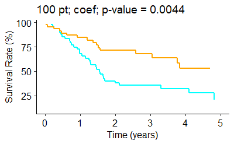

```r
# draw survival plot of Asian patients
pt100.drug <- survival::survfit(Surv(Survival.days, Vital.state) ~ Drug.subgroup,
                                data = clinical.data100pt, conf.type = 'log-log')

sum.100pt.drug <- surv_summary(pt100.drug, data = clinical.data100pt) %>% as.data.frame()

sum.100ptDrug <- convert(sum.100pt.drug)

FigS7C.OS100pt.coef <- ggplot() +
  geom_step(data = sum.100ptDrug,
            aes(x = time.year,
                y = surv,
                group = Drug.subgroup,
                color = Drug.subgroup,
                alpha = lty),
            size = 1) +
  scale_color_manual(values = c('CCA1' = 'cyan', 'CCA2' = 'orange')) +
  scale_shape_manual(values = c('CCA1' = 16, 'CCA2' = 16)) +
  scale_alpha_manual(values = c('drug' = 1,'molec' = 1)) +
  scale_size_manual(values = c('drug' = 1,'molec' = 1)) +
  scale_x_continuous(breaks = seq(0,8,1), limits = c(0,5)) +
  theme_pubr() +
  theme(
    # text = element_text(family = 'Arial', size = 10),
    # axis.text = element_text(family = 'Arial', size = 8),
    # axis.title = element_text(size = 10),
    legend.position = 'none'
  ) +
  # facet_grid(lty ~ .) +
  labs(x = 'Time (years)',
       y = 'Survival Rate (%)',
       title = paste0('100 pt; coef; p-value = ',round(summary(fit100pt.group)$coefficients[5],4)))

# use all CCA patients drug subtype 1
FigS7C.OS100pt.coef
```

Tally CCA subgroup 1 and 2 in 100 patients cohort

```r
clinical.data100pt %>% group_by(Drug.subgroup) %>% tally()
```

|  | Drug.subgroup | n |
| --- | --- | --- |
| 1 | 1 | 51 |
| 2 | 2 | 49 |

Save figure S7C

```r
# setwd('C:/Users/patipark/Dropbox/CCA project/CCA RNA-seq/NewGeneSet_Module_InitialAnalysis/Figure_5A_files')
# ggsave(FigS7C.OS100pt.coef,
#        filename = 'FigureS7C_OS100pt_Coef_20200326.pdf',
#        height = 4,
#        width = 6,
#        units = 'in',
#        device = cairo_pdf)
# dev.off()
```

Figure 6B Use results from Coef to predict OS of Asian patients Asian country patients

```r
# subset data for Asian patients only
clinical.dataAsia <- clinical.data %>% subset(Country %in% c('Singapore','Thailand','Korea'))

clinical.dataAsia$Drug.subgroup <- y_auc$pred.coef[match(clinical.dataAsia$ID,rownames(y_auc))]

# by group
Asfit.group <- coxph(Surv(Survival.days, Vital.state) ~ Drug.subgroup,
                   data = clinical.dataAsia)

summary(Asfit.group)
```

```
Call:
coxph(formula = Surv(Survival.days, Vital.state) ~ Drug.subgroup,
    data = clinical.dataAsia)

  n= 66, number of events= 32
   (1 observation deleted due to missingness)

                 coef exp(coef) se(coef)      z Pr(>|z|)
Drug.subgroup -1.0424    0.3526   0.3829 -2.723  0.00648 **
---
Signif. codes:  0 ‘***’ 0.001 ‘**’ 0.01 ‘*’ 0.05 ‘.’ 0.1 ‘ ’ 1

              exp(coef) exp(-coef) lower .95 upper .95
Drug.subgroup    0.3526      2.836    0.1665    0.7468

Concordance= 0.636  (se = 0.044 )
Likelihood ratio test= 8.1  on 1 df,   p=0.004
Wald test            = 7.41  on 1 df,   p=0.006
Score (logrank) test = 8.09  on 1 df,   p=0.004
```

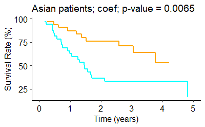

```r
# draw survival plot of Asian patients
Asian.drug <- survival::survfit(Surv(Survival.days, Vital.state) ~ Drug.subgroup,
                                data = clinical.dataAsia, conf.type = 'log-log')

sum.Asian.drug <- surv_summary(Asian.drug, data = clinical.dataAsia) %>% as.data.frame()

sum.AsDrug <- convert(sum.Asian.drug)

Fig6B.OS100pt.Asian <- ggplot() +
  geom_step(data = sum.AsDrug,
            aes(x = time.year,
                y = surv,
                group = Drug.subgroup,
                color = Drug.subgroup,
                alpha = lty),
            size = 1) +
  scale_color_manual(values = c('CCA1' = 'cyan', 'CCA2' = 'orange')) +
  scale_shape_manual(values = c('CCA1' = 16, 'CCA2' = 16)) +
  scale_alpha_manual(values = c('drug' = 1,'molec' = 1)) +
  scale_size_manual(values = c('drug' = 1,'molec' = 1)) +
  scale_x_continuous(breaks = seq(0,8,1), limits = c(0,5)) +
  theme_pubr() +
  theme(
    # text = element_text(family = 'Arial', size = 10),
    # axis.text = element_text(family = 'Arial', size = 8),
    # axis.title = element_text(size = 10),
    legend.position = 'none'
  ) +
  # facet_grid(lty ~ .) +
  labs(x = 'Time (years)',
       y = 'Survival Rate (%)',
       title = paste0('Asian patients; coef; p-value = ',round(summary(Asfit.group)$coefficients[5],4)))

# use all CCA patients drug subtype 1
Fig6B.OS100pt.Asian
```

Tally CCA subgroup 1 and 2 in Asian patients cohort

```r
clinical.dataAsia %>% group_by(Drug.subgroup) %>% tally()
```

|  | Drug.subgroup | n |
| --- | --- | --- |
| 1 | 1 | 34 |
| 2 | 2 | 33 |

Save figure 6B

```r
# setwd('C:/Users/patipark/Dropbox/CCA project/CCA RNA-seq/NewGeneSet_Module_InitialAnalysis/Figure_5A_files')
# ggsave(Fig6B.OS100pt.Asian,
#        filename = 'Figure6B_OSAsianpt_Coef_20200326.pdf',
#        height = 4,
#        width = 6,
#        units = 'in',
#        device = cairo_pdf)
# dev.off()
```

Figure S7D Use results from Coef to predict OS of Ov-infected patients

```r
# subset data for Thailand or OV-infected patients only
clinical.dataTH <- clinical.data %>% subset(Country %in% c('Thailand'))

clinical.dataTH$Drug.subgroup <- y_auc$pred.coef[match(clinical.dataTH$ID,rownames(y_auc))]

# by group
THfit.group <- coxph(Surv(Survival.days, Vital.state) ~ Drug.subgroup,
                   data = clinical.dataTH)

summary(THfit.group)
```

```
Call:
coxph(formula = Surv(Survival.days, Vital.state) ~ Drug.subgroup,
    data = clinical.dataTH)

  n= 36, number of events= 26
   (1 observation deleted due to missingness)

                 coef exp(coef) se(coef)      z Pr(>|z|)
Drug.subgroup -0.7624    0.4666   0.4474 -1.704   0.0884 .
---
Signif. codes:  0 ‘***’ 0.001 ‘**’ 0.01 ‘*’ 0.05 ‘.’ 0.1 ‘ ’ 1

              exp(coef) exp(-coef) lower .95 upper .95
Drug.subgroup    0.4666      2.143    0.1941     1.121

Concordance= 0.596  (se = 0.046 )
Likelihood ratio test= 3.2  on 1 df,   p=0.07
Wald test            = 2.9  on 1 df,   p=0.09
Score (logrank) test = 3.04  on 1 df,   p=0.08
```

Draw Figure S6E Surivial rate of Ov-infected patients.

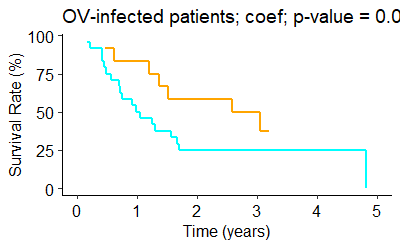

```r
# Draw survival plot for Thai or OV-infected group
TH.drug <- survival::survfit(Surv(Survival.days, Vital.state) ~ Drug.subgroup,
                                data = clinical.dataTH, conf.type = 'log-log')

sum.TH.drug <- surv_summary(TH.drug, data = clinical.dataTH) %>% as.data.frame()

sum.THDrug <- convert(sum.TH.drug)

FigS7D.OS100pt.TH <- ggplot() +
  geom_step(data = sum.THDrug,
            aes(x = time.year,
                y = surv,
                group = Drug.subgroup,
                color = Drug.subgroup,
                alpha = lty),
            size = 1) +
  scale_color_manual(values = c('CCA1' = 'cyan', 'CCA2' = 'orange')) +
  scale_shape_manual(values = c('CCA1' = 16, 'CCA2' = 16)) +
  scale_alpha_manual(values = c('drug' = 1,'molec' = 1)) +
  scale_size_manual(values = c('drug' = 1,'molec' = 1)) +
  scale_x_continuous(breaks = seq(0,8,1), limits = c(0,5)) +
  theme_pubr() +
  theme(
    # text = element_text(family = 'Arial', size = 10),
    # axis.text = element_text(family = 'Arial', size = 8),
    # axis.title = element_text(size = 10),
    legend.position = 'none'
  ) +
  # facet_grid(lty ~ .) +
  labs(x = 'Time (years)',
       y = 'Survival Rate (%)',
       title = paste0('OV-infected patients; coef; p-value = ',round(summary(THfit.group)$coefficients[5],4)))

# use all CCA patients drug subtype 1
FigS7D.OS100pt.TH
```

Tally CCA subgroup 1 and 2 in OV-infected patients cohort

```r
clinical.dataTH %>% group_by(Drug.subgroup) %>% tally()
```

|  | Drug.subgroup | n |
| --- | --- | --- |
| 1 | 1 | 24 |
| 2 | 2 | 13 |

Save figure S6E.

```r
# setwd('C:/Users/patipark/Dropbox/CCA project/CCA RNA-seq/NewGeneSet_Module_InitialAnalysis/Figure_5A_files')
# ggsave(OS100pt.TH,
#        filename = 'FigureS7D_OSOVpt_Coef_20200326.pdf',
#        height = 4,
#        width = 6,
#        units = 'in',
#        device = cairo_pdf)
# dev.off()
```

Figure 6C Use results from Coef to predict OS of non-Asian patients

```r
# subset data
clinical.dataEU <- clinical.data %>% subset(!Country %in% c('Singapore','Thailand','Korea'))

clinical.dataEU$Drug.subgroup <- y_auc$pred.coef[match(clinical.dataEU$ID,rownames(y_auc))]

# by group
EUfit.group <- coxph(Surv(Survival.days, Vital.state) ~ Drug.subgroup,
                   data = clinical.dataEU)

summary(EUfit.group)
```

```
Call:
coxph(formula = Surv(Survival.days, Vital.state) ~ Drug.subgroup,
    data = clinical.dataEU)

  n= 31, number of events= 17
   (2 observations deleted due to missingness)

                 coef exp(coef) se(coef)      z Pr(>|z|)
Drug.subgroup -0.5713    0.5648   0.5108 -1.119    0.263

              exp(coef) exp(-coef) lower .95 upper .95
Drug.subgroup    0.5648      1.771    0.2076     1.537

Concordance= 0.53  (se = 0.073 )
Likelihood ratio test= 1.31  on 1 df,   p=0.3
Wald test            = 1.25  on 1 df,   p=0.3
Score (logrank) test = 1.28  on 1 df,   p=0.3
```

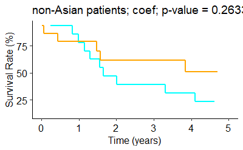

```r
# Draw survival plot for non-Asian group
EU.drug <- survival::survfit(Surv(Survival.days, Vital.state) ~ Drug.subgroup,
                                data = clinical.dataEU, conf.type = 'log-log')

sum.EU.drug <- surv_summary(EU.drug, data = clinical.dataEU) %>% as.data.frame()

sum.EUDrug <- convert(sum.EU.drug)

Fig6C.OS100pt.EU <- ggplot() +
  geom_step(data = sum.EUDrug,
            aes(x = time.year,
                y = surv,
                group = Drug.subgroup,
                color = Drug.subgroup,
                alpha = lty),
            size = 1) +
  scale_color_manual(values = c('CCA1' = 'cyan', 'CCA2' = 'orange')) +
  scale_shape_manual(values = c('CCA1' = 16, 'CCA2' = 16)) +
  scale_alpha_manual(values = c('drug' = 1,'molec' = 1)) +
  scale_size_manual(values = c('drug' = 1,'molec' = 1)) +
  scale_x_continuous(breaks = seq(0,8,1), limits = c(0,5)) +
  theme_pubr() +
  theme(
    # text = element_text(family = 'Arial', size = 10),
    # axis.text = element_text(family = 'Arial', size = 8),
    # axis.title = element_text(size = 10),
    legend.position = 'none'
  ) +
  # facet_grid(lty ~ .) +
  labs(x = 'Time (years)',
       y = 'Survival Rate (%)',
       title = paste0('non-Asian patients; coef; p-value = ',round(summary(EUfit.group)$coefficients[5],4)))

# use all CCA patients drug subtype 1
Fig6C.OS100pt.EU
```

Tally CCA subgroup 1 and 2 in EU patients cohort

```r
clinical.dataEU %>% group_by(Drug.subgroup) %>% tally()
```

|  | Drug.subgroup | n |
| --- | --- | --- |
| 1 | 1 | 17 |
| 2 | 2 | 16 |

Save figure 6C

```r
# setwd('C:/Users/patipark/Dropbox/CCA project/CCA RNA-seq/NewGeneSet_Module_InitialAnalysis/Figure_5A_files')
# ggsave(Fig6C.OS100pt.EU,
#        filename = 'Figure6C_OSEUpt_Coef_20200326.pdf',
#        height = 4,
#        width = 6,
#        units = 'in',
#        device = cairo_pdf)
# dev.off()
```

Calculate 1- and 3-year survival rate

```r
# 100 patients cohort
OneYear.pt100.drug <- summary(survfit(Surv(Survival.days, Vital.state) ~ Drug.subgroup,
                                data = clinical.data100pt, conf.type = 'log-log'),
                              times = 365.25)
ThreeYear.pt100.drug <- summary(survfit(Surv(Survival.days, Vital.state) ~ Drug.subgroup,
                                data = clinical.data100pt, conf.type = 'log-log'),
                              times = 365.25*3)
# Asian vs non-Asian
# Asian CCA
OneYear.Asian <- summary(survfit(Surv(Survival.days, Vital.state) ~ Drug.subgroup,
                                data = clinical.dataAsia, conf.type = 'log-log'),
                              times = 365.25)
ThreeYear.Asian <- summary(survfit(Surv(Survival.days, Vital.state) ~ Drug.subgroup,
                                data = clinical.dataAsia, conf.type = 'log-log'),
                              times = 365.25*3)
# non-Asian CCA
OneYear.nonAsian <- summary(survfit(Surv(Survival.days, Vital.state) ~ Drug.subgroup,
                                data = clinical.dataEU, conf.type = 'log-log'),
                              times = 365.25)
ThreeYear.nonAsian <- summary(survfit(Surv(Survival.days, Vital.state) ~ Drug.subgroup,
                                data = clinical.dataEU, conf.type = 'log-log'),
                              times = 365.25*3)

# Ov+ vs Ov-
# Ov+
OneYear.OvPos <- summary(survfit(Surv(Survival.days, Vital.state) ~ Drug.subgroup,
                                data = clinical.dataTH, conf.type = 'log-log'),
                              times = 365.25)
ThreeYear.OvPos <- summary(survfit(Surv(Survival.days, Vital.state) ~ Drug.subgroup,
                                data = clinical.dataTH, conf.type = 'log-log'),
                              times = 365.25*3)

# These data will be used to plot Figure 7

# create a report table
SurvRateTable <- rbind(OneYear.pt100.drug$surv,
      OneYear.Asian$surv,
      OneYear.nonAsian$surv,
      OneYear.OvPos$surv,
      ThreeYear.pt100.drug$surv,
      ThreeYear.Asian$surv,
      ThreeYear.nonAsian$surv,
      ThreeYear.OvPos$surv) %>% as.data.frame()

colnames(SurvRateTable) <- c('CCA1','CCA2')

# add Period and Group
Period <- c(1,1,1,1,3,3,3,3)
Group <- rep(c('All','Asian','non-Asian','Ov-Pos'),2)

SurvRateTable <- tibble::add_column(SurvRateTable,Period,.before = 1)

SurvRateTable <- tibble::add_column(SurvRateTable,Group,.before = 1)

nTable <- rbind(OneYear.pt100.drug$n,
      OneYear.Asian$n,
      OneYear.nonAsian$n,
      OneYear.OvPos$n,
      ThreeYear.pt100.drug$n,
      ThreeYear.Asian$n,
      ThreeYear.nonAsian$n,
      ThreeYear.OvPos$n) %>% as.data.frame()

colnames(nTable) <- c('CCA1','CCA2')
# add Period and Group
Period <- c(1,1,1,1,3,3,3,3)
Group <- rep(c('All','Asian','non-Asian','Ov-Pos'),2)

nTable <- tibble::add_column(nTable,Period,.before = 1)

nTable <- tibble::add_column(nTable,Group,.before = 1)

myOS.table <- melt(SurvRateTable,id.var = c('Group','Period'), variable.name = 'Subtype', value.name = 'SurvRate')

myn.table <- melt(nTable,id.var = c('Group','Period'), variable.name = 'Subtype', value.name = 'n')

mysum.table <- merge(x = myOS.table, y = myn.table, by = c('Group','Period','Subtype'))
```

Save survival rate table

```r
setwd('C:/Users/patipark/Dropbox/CCA project/CCA RNA-seq/NewGeneSet_Module_InitialAnalysis/Figure_5A_files')
write.csv(mysum.table,file = 'SurvivalRate_allGroups_20200827.csv', row.names = FALSE)
```

Distribution of molecular subtypes in CCA subtypes Figure S6F In 100-patient cohort Compare predicted classes by unsupervised and supervised clustering methods

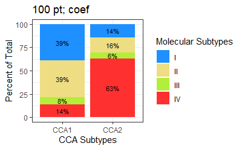

```r
apyi <- clinical.data %>% dplyr::select(ID,Fluke.Infection,Country,Cluster,Drug.subgroup)

# use drug subgroup from Coef
apyi$Drug.subgroup <- y_auc$pred.coef[match(apyi$ID,rownames(y_auc))]

colnames(apyi)[4] <- 'molec.class'
colnames(apyi)[5] <- 'pred.class'
# count CCA drug subtypes resulting from supervised prediction
ptcounts <- apyi %>% count(molec.class,pred.class, name = 'tally')

# remove NA (CCA cell lines)
ptcounts <- ptcounts[!is.na(ptcounts$molec.class),]

ptcounts <- ptcounts %>% group_by(pred.class) %>%
  mutate(percent = (tally / (tally[molec.class == 1] +
                             tally[molec.class == 2] +
                             tally[molec.class == 3] +
                             tally[molec.class == 4])) * 100)

# change Cx to Mx
ptcounts$molec.class <- ifelse(ptcounts$molec.class == 1,'I',
                               ifelse(ptcounts$molec.class == 2,'II',
                                      ifelse(ptcounts$molec.class == 3,'III','IV')))

# change pred.class from c(1,2) to c('CCA1','CCA2')
ptcounts$pred.class <- ifelse(ptcounts$pred.class == 1,'CCA1','CCA2')

# add factor level
ptcounts$pred.class <- factor(ptcounts$pred.class, levels = c('CCA1','CCA2'))

myFigS7E.100pt.Coef <- ggplot(ptcounts,
                aes(x = pred.class,
                    y = percent,
                    fill = molec.class,
                    label = paste0(sprintf("%0.0f", round(percent, digits = 1)),'%'))) +
  geom_col() +
  scale_fill_manual(values = c('I' = 'dodgerblue','II' = 'lightgoldenrod',
                               'III' = 'olivedrab2','IV' = 'firebrick1')) +
  geom_text(size = 3, position = position_stack(vjust = 0.5)) +
  theme_bw() +
  theme(
    # text = element_text(family = 'Arial'),
  ) +
  # facet_grid(. ~ Clustering, space = 'free', scales = 'free') +
  labs(x = 'CCA Subtypes',
       y = 'Percent of Total',
       fill = 'Molecular Subtypes',
       title = '100 pt; coef')

myFigS7E.100pt.Coef
```

Save figure S6F.

```r
# setwd('C:/Users/patipark/Dropbox/CCA project/CCA RNA-seq/NewGeneSet_Module_InitialAnalysis/Figure_5A_files')
# ggsave(myFigS7E.5C100pt.Coef,
#        filename = 'FigureS7E_Tally100pt_Coef_20200326.pdf',
#        height = 3,
#        width = 4,
#        units = 'in',
#        device = cairo_pdf)
# dev.off()
```

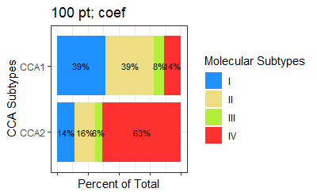

```r
ptcounts$pred.class <- factor(ptcounts$pred.class, levels = c('CCA2','CCA1'))
CCAtoMolec <- ggplot(ptcounts,
                aes(x = pred.class,
                    y = desc(percent),
                    fill = molec.class,
                    label = paste0(sprintf("%0.0f", round(percent, digits = 1)),'%'))) +
  geom_bar(stat = 'identity') +
  scale_fill_manual(values = c('I' = 'dodgerblue','II' = 'lightgoldenrod',
                               'III' = 'olivedrab2','IV' = 'firebrick1')) +
  geom_text(size = 3, position = position_stack(vjust = 0.5)) +
  theme_bw() +
  theme(
    axis.text.x = element_blank()
  ) +
  # facet_grid(. ~ Clustering, space = 'free', scales = 'free') +
  labs(x = 'CCA Subtypes',
       y = 'Percent of Total',
       fill = 'Molecular Subtypes',
       title = '100 pt; coef') +
  coord_flip()

CCAtoMolec
```

Part of Figure 7 Asian v. non-Asian fraction in CCA subtypes

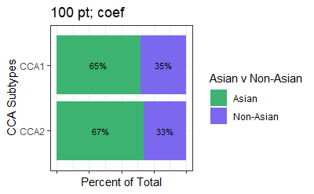

```r
# use 100-pt data
apyi <- clinical.data %>% dplyr::select(ID,Fluke.Infection,Country,Cluster,Drug.subgroup)

# use drug subgroup from Coef
apyi$Drug.subgroup <- y_auc$pred.coef[match(apyi$ID,rownames(y_auc))]

# add Asian/non-Asian groups
Asian.Countries <- c('Thailand','Singapore','Thailand')
apyi$Asian <- ifelse(apyi$Country %in% Asian.Countries, 1, 0)

CCA.Countries <- c('Thailand')
apyi$CCA <- ifelse(apyi$Country %in% CCA.Countries, 1, 0)

colnames(apyi)[4] <- 'molec.class'
colnames(apyi)[5] <- 'pred.class'
# count CCA drug subtypes resulting from supervised prediction
Asian.counts <- apyi %>% count(pred.class,Asian, name = 'tally')
CCA.counts <- apyi %>% count(pred.class,CCA, name = 'tally')
Molec.counts <- apyi %>% count(molec.class,Asian, name = 'tally')

AScounts <- Asian.counts %>% group_by(pred.class) %>%
  mutate(percent = (tally / (tally[Asian == 1] +
                             tally[Asian == 0])) * 100)

# change pred.class from c(1,2) to c('CCA1','CCA2')
AScounts$pred.class <- ifelse(AScounts$pred.class == 1,'CCA1','CCA2')
AScounts$Asian <- ifelse(AScounts$Asian == 1,'Asian','Non-Asian')

# add factor level
AScounts$pred.class <- factor(AScounts$pred.class, levels = c('CCA2','CCA1'))
AScounts$Asian <- factor(AScounts$Asian, levels = c('Asian','Non-Asian'))

CCASubtypetoAsian <- ggplot(AScounts,
                aes(x = pred.class,
                    y = desc(percent),
                    fill = Asian,
                    label = paste0(sprintf("%0.0f", round(percent, digits = 1)),'%'))) +
  geom_bar(stat = 'identity') +
  scale_fill_manual(values = c('Asian' = 'mediumseagreen','Non-Asian' = 'mediumslateblue')) +
  geom_text(size = 3, position = position_stack(vjust = 0.5)) +
  theme_bw() +
  theme(
    axis.text.x = element_blank()
  ) +
  # facet_grid(. ~ Clustering, space = 'free', scales = 'free') +
  labs(x = 'CCA Subtypes',
       y = 'Percent of Total',
       fill = 'Asian v Non-Asian',
       title = '100 pt; coef') +
  coord_flip()

CCASubtypetoAsian
```

CCASubtype to CCA infection

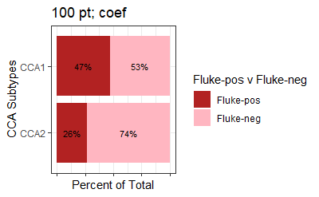

```r
Flukecounts <- CCA.counts %>% group_by(pred.class) %>%
  mutate(percent = (tally / (tally[CCA == 1] +
                             tally[CCA == 0])) * 100)

# change pred.class from c(1,2) to c('CCA1','CCA2')
Flukecounts$pred.class <- ifelse(Flukecounts$pred.class == 1,'CCA1','CCA2')
Flukecounts$CCA <- ifelse(Flukecounts$CCA == 1,'Fluke-pos','Fluke-neg')

# add factor level
Flukecounts$pred.class <- factor(Flukecounts$pred.class, levels = c('CCA2','CCA1'))
Flukecounts$CCA <- factor(Flukecounts$CCA, levels = c('Fluke-pos','Fluke-neg'))

CCASubtypetoFluke <- ggplot(Flukecounts,
                aes(x = pred.class,
                    y = desc(percent),
                    fill = CCA,
                    label = paste0(sprintf("%0.0f", round(percent, digits = 1)),'%'))) +
  geom_bar(stat = 'identity') +
  scale_fill_manual(values = c('Fluke-pos' = 'firebrick','Fluke-neg' = 'lightpink')) +
  geom_text(size = 3, position = position_stack(vjust = 0.5)) +
  theme_bw() +
  theme(
    axis.text.x = element_blank()
  ) +
  # facet_grid(. ~ Clustering, space = 'free', scales = 'free') +
  labs(x = 'CCA Subtypes',
       y = 'Percent of Total',
       fill = 'Fluke-pos v Fluke-neg',
       title = '100 pt; coef') +
  coord_flip()

CCASubtypetoFluke
```

Save images for Figure 7

```r
# threeFigures <- grid.arrange(CCAtoMolec,CCASubtypetoAsian,CCASubtypetoFluke, nrow = 3, ncol = 1)
#
# setwd('C:/Users/patipark/Dropbox/CCA project/CCA RNA-seq/NewGeneSet_Module_InitialAnalysis/Figure_5A_files')
# ggsave(threeFigures,
#        filename = 'Figure7_CCASubtypes_202000528.pdf',
#        height = 4,
#        width = 5,
#        units = 'in',
#        device = cairo_pdf)
# dev.off()
```

Figure 7C. Distribution of CCA molecular subtypes in CCA drug response subtypes. In Asian patient only cohort Compare predicted classes by unsupervised and supervised clustering methods

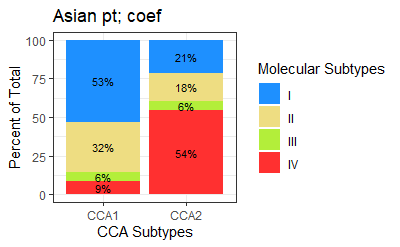

```r
apyi.As <- clinical.data %>% dplyr::select(ID,Fluke.Infection,Country,Cluster,Drug.subgroup) %>%
  subset(Country %in% c('Thailand','Singapore','Korea'))

# use drug subgroup from Coef
apyi.As$Drug.subgroup <- y_auc$pred.coef[match(apyi.As$ID,rownames(y_auc))]

colnames(apyi.As)[4] <- 'molec.class'
colnames(apyi.As)[5] <- 'pred.class'
# count CCA drug subtypes resulting from supervised prediction
ptcounts <- apyi.As %>% count(molec.class,pred.class, name = 'tally')

# remove NA (CCA cell lines)
ptcounts <- ptcounts[!is.na(ptcounts$molec.class),]

ptcounts <- ptcounts %>% group_by(pred.class) %>%
  mutate(percent = (tally / (tally[molec.class == 1] +
                             tally[molec.class == 2] +
                             tally[molec.class == 3] +
                             tally[molec.class == 4])) * 100)

# change Cx to Mx
ptcounts$molec.class <- ifelse(ptcounts$molec.class == 1,'I',
                               ifelse(ptcounts$molec.class == 2,'II',
                                      ifelse(ptcounts$molec.class == 3,'III','IV')))

# change pred.class from c(1,2) to c('CCA1','CCA2')
ptcounts$pred.class <- ifelse(ptcounts$pred.class == 1,'CCA1','CCA2')

# add factor level
ptcounts$pred.class <- factor(ptcounts$pred.class, levels = c('CCA1','CCA2'))

myFig6D.Aspt.Coef <- ggplot(ptcounts,
                aes(x = pred.class,
                    y = percent,
                    fill = molec.class,
                    label = paste0(sprintf("%0.0f", round(percent, digits = 1)),'%'))) +
  geom_col() +
  scale_fill_manual(values = c('I' = 'dodgerblue','II' = 'lightgoldenrod',
                               'III' = 'olivedrab2','IV' = 'firebrick1')) +
  geom_text(size = 3, position = position_stack(vjust = 0.5)) +
  theme_bw() +
  theme(
    # text = element_text(family = 'Arial'),
  ) +
  # facet_grid(. ~ Clustering, space = 'free', scales = 'free') +
  labs(x = 'CCA Subtypes',
       y = 'Percent of Total',
       fill = 'Molecular Subtypes',
       title = 'Asian pt; coef')

myFig6D.Aspt.Coef
```

Save figure 7C.

```r
# setwd('C:/Users/patipark/Dropbox/CCA project/CCA RNA-seq/NewGeneSet_Module_InitialAnalysis/Figure_5A_files')
# ggsave(myFig6D.Aspt.Coef,
#        filename = 'Figure_TallyASpt_Coef_20200326.pdf',
#        height = 3,
#        width = 4,
#        units = 'in',
#        device = cairo_pdf)
# dev.off()
```

Figure 7C. Distribution of molecular subtypes in each drug response subtype in Non-Asian population.

```r
apyi.nonAs <- clinical.data %>% dplyr::select(ID,Fluke.Infection,Country,Cluster,Drug.subgroup) %>%
  subset(!Country %in% c('Thailand','Singapore','Korea'))

# use drug subgroup from Coef
apyi.nonAs$Drug.subgroup <- y_auc$pred.coef[match(apyi.nonAs$ID,rownames(y_auc))]

colnames(apyi.nonAs)[4] <- 'molec.class'
colnames(apyi.nonAs)[5] <- 'pred.class'
# count CCA drug subtypes resulting from supervised prediction
# add factor level to numeric data
apyi.nonAs <- apyi.nonAs %>% modify_if(is.numeric, as.factor)

# .drop = FALSE to preserv zero count group
ptcounts <- apyi.nonAs %>% group_by(molec.class,pred.class,.drop = FALSE) %>% tally(.,name = 'tally')

# remove NA (CCA cell lines)
ptcounts <- ptcounts[!is.na(ptcounts$molec.class),]

ptcounts <- ptcounts %>% group_by(pred.class) %>%
  mutate(percent = (tally / (tally[molec.class == 1] +
                             tally[molec.class == 2] +
                             tally[molec.class == 3] +
                             tally[molec.class == 4])) * 100)

# change Cx to Mx
ptcounts$molec.class <- ifelse(ptcounts$molec.class == 1,'I',
                               ifelse(ptcounts$molec.class == 2,'II',
                                      ifelse(ptcounts$molec.class == 3,'III','IV')))

# change pred.class from c(1,2) to c('CCA1','CCA2')
ptcounts$pred.class <- ifelse(ptcounts$pred.class == 1,'CCA1','CCA2')

# add factor level
ptcounts$pred.class <- factor(ptcounts$pred.class, levels = c('CCA1','CCA2'))

myFig7C.nonAspt.Coef <- ggplot(ptcounts,
                aes(x = pred.class,
                    y = percent,
                    fill = molec.class,
                    label = paste0(sprintf("%0.0f", round(percent, digits = 1)),'%'))) +
  geom_col() +
  scale_fill_manual(values = c('I' = 'dodgerblue','II' = 'lightgoldenrod',
                               'III' = 'olivedrab2','IV' = 'firebrick1')) +
  geom_text(size = 3, position = position_stack(vjust = 0.5)) +
  theme_bw() +
  theme(
    # text = element_text(family = 'Arial'),
  ) +
  # facet_grid(. ~ Clustering, space = 'free', scales = 'free') +
  labs(x = 'CCA Subtypes',
       y = 'Percent of Total',
       fill = 'Molecular Subtypes',
       title = 'non-Asian pt; coef')

myFig7C.nonAspt.Coef
```

Save Figure 7C distribution of molecular subtypes in drug subgroups for non-Asian patients

```r
# setwd('C:/Users/patipark/Dropbox/CCA project/CCA RNA-seq/NewGeneSet_Module_InitialAnalysis/Figure_5A_files')
# ggsave(myFig6E.nonAspt.Coef,
#        filename = 'Figure6E_TallyNonASpt_Coef_20200421.pdf',
#        height = 3,
#        width = 4,
#        units = 'in',
#        device = cairo_pdf)
# dev.off()
```

Tally for OV-infection in Asian population

```r
###
apyi.As$infect <- clinical.data$Fluke.Infection[match(apyi.As$ID,clinical.data$ID)]

infcounts <- apyi.As %>% subset(dataset = 'apinya') %>% count(pred.class,infect, name = 'tally')
infcounts <- infcounts %>% group_by(pred.class) %>%
  mutate(percent = (tally / (tally[infect == 'Fluke-Pos'] + tally[infect == 'Fluke-Neg'])) * 100)

infcounts$infect <- ifelse(infcounts$infect == 'Fluke-Pos', 'Pos','Neg')

infcounts$infect <- factor(infcounts$infect, levels = c('Pos','Neg'))

myFigOV.Coef <- ggplot(infcounts,
       aes(x = pred.class,
           y = percent,
           fill = infect,
           label = paste0(sprintf("%0.0f", round(percent, digits = 1)),'%'))) +
  geom_col() +
  scale_fill_manual(values = c('Pos' = 'firebrick','Neg' = 'lightpink')) +
  geom_text(size = 3, position = position_stack(vjust = 0.5)) +
  theme_bw() +
  theme(
    # text = element_text(family = 'Arial'),
  ) +
  # facet_grid(. ~ Clustering, space = 'free', scales = 'free') +
  labs(x = 'CCA Subtype',
       y = 'Percent of Total',
       fill = 'Fluke Infection',
       title = 'Asian patients')

myFigOV.Coef
```

Figure S6G. Distribution of molecular subtypes in each CCA drug response subtypes in Ov-infected population.

```r
apyi.As$infect <- clinical.data$Fluke.Infection[match(apyi.As$ID,clinical.data$ID)]

apyiOv <- apyi.As %>% subset(Fluke.Infection == 'Fluke-Pos') %>% modify_if(is.numeric, as.factor)

# .drop = FALSE to preserv zero count group
ptcounts <- apyiOv %>% group_by(molec.class,pred.class,.drop = FALSE) %>% tally(.,name = 'tally')

# remove NA (CCA cell lines)
ptcounts <- ptcounts[!is.na(ptcounts$molec.class),]

ptcounts <- ptcounts %>% group_by(pred.class) %>%
  mutate(percent = (tally / (tally[molec.class == 1] +
                             tally[molec.class == 2] +
                             tally[molec.class == 3] +
                             tally[molec.class == 4])) * 100)

# change Cx to Mx
ptcounts$molec.class <- ifelse(ptcounts$molec.class == 1,'I',
                               ifelse(ptcounts$molec.class == 2,'II',
                                      ifelse(ptcounts$molec.class == 3,'III','IV')))

# change pred.class from c(1,2) to c('CCA1','CCA2')
ptcounts$pred.class <- ifelse(ptcounts$pred.class == 1,'CCA1','CCA2')

# add factor level
ptcounts$pred.class <- factor(ptcounts$pred.class, levels = c('CCA1','CCA2'))

myFigS6G.Ovpt.Coef <- ggplot(ptcounts,
                aes(x = pred.class,
                    y = percent,
                    fill = molec.class,
                    label = paste0(sprintf("%0.0f", round(percent, digits = 1)),'%'))) +
  geom_col() +
  scale_fill_manual(values = c('I' = 'dodgerblue','II' = 'lightgoldenrod',
                               'III' = 'olivedrab2','IV' = 'firebrick1')) +
  geom_text(size = 3, position = position_stack(vjust = 0.5)) +
  theme_bw() +
  theme(
    # text = element_text(family = 'Arial'),
  ) +
  # facet_grid(. ~ Clustering, space = 'free', scales = 'free') +
  labs(x = 'CCA Subtypes',
       y = 'Percent of Total',
       fill = 'Molecular Subtypes',
       title = 'Ov-infected pt; coef')

myFigS6G.Ovpt.Coef
```

Save Figure S6G distribution of molecular subtypes in drug subgroups for Ov-infected patients

```r
# setwd('C:/Users/patipark/Dropbox/CCA project/CCA RNA-seq/NewGeneSet_Module_InitialAnalysis/Figure_5A_files')
# ggsave(myFigS7F.Ovpt.Coef,
#        filename = 'FigureS7F_TallyOvpt_Coef_20200421.pdf',
#        height = 3,
#        width = 4,
#        units = 'in',
#        device = cairo_pdf)
# dev.off()
```

Figure S7B Apply tSNE to the gene expression dataset to display landscape of the samples (CCA cell lines and patients) based on gene expression data.

```r
require(Rtsne)
set.seed(12345)
tsne_out <- Rtsne(as.matrix(t(myMatrix2.Coef5)),
                  initial_dims = 20, # Cumsum(PoV) = 80%
                  perplexity = 30, # N^(1/2) = 11
                  theta = 0.5,
                  max_iter = 1000) # Run TSNE

# extract tsne1 and tsne2
tsne.result <- tsne_out$Y %>% as.data.frame()
rownames(tsne.result) <- colnames(myMatrix2.Coef5)
colnames(tsne.result) <- c('tSNE1','tSNE2')

# assign drug subgroup from unsupervised hierarchical clusters to data table
tsne.result$drug.group <- y_auc$ref.cluster[match(rownames(tsne.result),rownames(y_auc))]
# assign drug subgroup to CCA cell lines
tsne.result$drug.group <- ifelse(rownames(tsne.result) %in% to[1:6], 1,
                                 ifelse(rownames(tsne.result) %in% to[7:15], 2, tsne.result$drug.group))

# change drug subgroup to CCA1 and CCA2
tsne.result$drug.group <- ifelse(tsne.result$drug.group == 1,'CCA1','CCA2')

# add factor levels to drug subgroup
tsne.result$drug.group <- factor(tsne.result$drug.group, levels = c('CCA1','CCA2'))

# add data set
tsne.result$dataset <- ifelse(rownames(tsne.result) %in% to,'cells','patient')

# add factor levels to data set
tsne.result$dataset <- factor(tsne.result$dataset, levels = c('cells','patient'))

# add molecular subgroup
tsne.result$molec.group <- paste0('M',apyi$molec.class[match(rownames(tsne.result),apyi$ID)])
tsne.result$molec.group <- ifelse(rownames(tsne.result) %in% to, 'unk', tsne.result$molec.group)

# move rownames to column
tsne.result <- tibble::rownames_to_column(tsne.result, var = 'ID')

tsne.result <- tsne.result %>% mutate(molec.group = case_when(molec.group == 'M1' ~ 'I',
                                                              molec.group == 'M2' ~ 'II',
                                                              molec.group == 'M3' ~ 'III',
                                                              molec.group == 'M4' ~ 'IV',
                                                              TRUE ~ molec.group))

# add factor levels to molec.group
tsne.result$molec.group <- factor(tsne.result$molec.group, levels = c('I','II','III','IV','unk'))

# subset data for ploting
# CCA cell lines
tsne.cca <- tsne.result %>% subset(dataset == 'cells')
# CCA patients
tsne.pt <- tsne.result %>% subset(dataset == 'patient')
```

```r
## use the original data set from tSNE results
tsne.d <- tsne.result[,c('tSNE1','tSNE2')]
rownames(tsne.d) <- tsne.result$ID

# add cluster label from hierarchical clusters
tsne.d$cl_hierarchical <- y_auc$ref.cluster[match(rownames(tsne.d),rownames(y_auc))]

# add cluster label of CCA cell lines
tsne.d$cl_hierarchical <- ifelse(rownames(tsne.d) %in% to[1:6], 1,
                                 ifelse(rownames(tsne.d) %in% to[7:15], 2,
                                        tsne.d$cl_hierarchical))
```

Use non-linear SVM to predict decision boundary

```r
# select data for svm data input
svm.dat <- tsne.d %>% dplyr::select(tSNE1,tSNE2,cl_hierarchical)

# add factor level to clusters
svm.dat$cl_hierarchical <- as.factor(svm.dat$cl_hierarchical)

# build a SVM model. Scale is FALSE because tSNEs are already scaled.
set.seed(100)
svm.fit <- e1071::svm(cl_hierarchical ~ .,
                      data = svm.dat,
                      scale = FALSE,
                      kernel = 'radial'
                      )

# build grid for boundary line
make.grid <- function(x, n = 100) {
  grange = apply(x, 2, range)
  x1 = seq(from = grange[1,1], to = grange[2,1], length = n)
  x2 = seq(from = grange[1,2], to = grange[2,2], length = n)
  expand.grid(X1 = x1, X2 = x2)
}

xdat <- svm.dat %>% dplyr::select(tSNE1,tSNE2)

xgrid <- make.grid(xdat)

colnames(xgrid) <- c('tSNE1','tSNE2')

ygrid <- predict(svm.fit, xgrid[,c('tSNE1','tSNE2')])

xgrid$group <- ygrid

xgrid$group <- ifelse(xgrid$group == 1,'C1','C2')

func <- predict(svm.fit, xgrid[,c('tSNE1','tSNE2')], decision.values = TRUE)

func <- attributes(func)$decision

xgrid$z <- func
```

```r
# create data for drug and molecular subgroups
tsne.my <- tsne.d %>% dplyr::select(tSNE1,tSNE2,cl_hierarchical)

tsne.my <- tibble::rownames_to_column(tsne.my, var = 'ID')

tsne.my$group <- clinical.data$Cluster[match(tsne.my$ID,clinical.data$ID)]

tsne.my$group <- ifelse(tsne.my$ID %in% to[1:6], 'C1',
                        ifelse(tsne.my$ID %in% to[7:15], 'C2', tsne.my$group))

tsne.my <- tsne.my %>% mutate(group = case_when(group == 1 ~ 'I',
                                                group == 2 ~ 'II',
                                                group == 3 ~ 'III',
                                                group == 4 ~ 'IV',
                                                TRUE ~ group),
                              dataset = ifelse(ID %in% to, 'cca', 'patient'))

# add factor level
tsne.my$group <- factor(tsne.my$group, levels = c('C1','C2','I','II','III','IV','unk'))
tsne.my$dataset <- factor(tsne.my$dataset, levels = c('cca','patient'))

# add factor level to grid data
xgrid$group <- factor(xgrid$group, levels = c('C1','C2','I','II','III','IV','unk'))

# subset CCA data
tsne.cca <- tsne.my %>% subset(ID %in% to)

# subset patient data
tsne.pt <- tsne.my %>% subset(!ID %in% to)
```

```r
require(ggrepel)
figS7B <- ggplot() +
  # geom_tile(data = xgrid,
  #           aes(x = tSNE1,
  #               y = tSNE2,
  #               fill = group),
  #           alpha = 0.1) +
  geom_contour(data = xgrid,
               aes(x = tSNE1,
                   y = tSNE2,
                   z = z), bins = 1, color = 'gray50', lty = 'dashed') +
  geom_point(data = tsne.cca,
             aes(x = tSNE1,
                 y = tSNE2,
                 # color = group,
                 fill = group,
                 shape = dataset),
             size = 5) +
  geom_point(data = tsne.pt,
             aes(x = tSNE1,
                 y = tSNE2,
                 # color = group,
                 fill = group,
                 shape = dataset),
             size = 2) +
  scale_fill_manual(values = c('C1' = 'cyan','C2' = 'orange',
                               'I' = 'dodgerblue','II' = 'lightgoldenrod',
                               'III' = 'olivedrab2','IV' = 'firebrick1',
                               'unk' = 'gray50')) +
  # scale_color_manual(values = c('C1' = 'cyan','C2' = 'orange',
  #                               'I' = 'dodgerblue','II' = 'lightgoldenrod',
  #                               'III' = 'olivedrab2','IV' = 'firebrick1',
  #                               'unk' = 'gray50')) +
  scale_shape_manual(values = c('cca' = 21,
                                'patient' = 24),
                     labels = c('cca' = 'Cells',
                                'patient' = 'Patients')) +
  geom_text_repel(data = tsne.cca,
                  aes(x = tSNE1,
                      y = tSNE2,
                      label = ID),
                  size = 3,
                  nudge_x = 0.2,
                  nudge_y = 0.2) +
  labs(
    x = 'tSNE1',
    y = 'tSNE2'
  ) +
  theme_minimal() +
  theme(
    # text = element_text(family = 'Arial'),
    legend.title = element_text(size = 8),
    legend.text = element_text(size = 6),
    axis.text = element_text(size = 6),
    axis.title = element_text(size = 8),
    legend.direction = 'vertical'
  ) +

  guides(fill = guide_legend(override.aes = list(shape = 21)))

figS7B
```

Save figure S7B

```r
# setwd('C:/Users/patipark/Dropbox/CCA project/CCA RNA-seq/NewGeneSet_Module_InitialAnalysis/Figure_5A_files')
# ggsave(figS7B,
#        filename = 'FigureS7B_tSNE_20200402.pdf',
#        height = 5,
#        width = 6,
#        units = 'in',
#        device = cairo_pdf)
# dev.off()
```

Part of Figure 7

```r
# create report table
SumTable <- data.frame('X.year.Surv' = rep(c(1,1,3,3),4),
           'Cohort' = c(rep('PT100',4),
                        rep('Asian',4),
                        rep('non-Asian',4),
                        rep('OvPos',4)),
           'CCA.Subtype' = c(rep(c('CCA1','CCA2'),4)),
           'Surv.Rate' = c(OneYear.pt100.drug$surv,
                           ThreeYear.pt100.drug$surv,
                           OneYear.Asian$surv,
                           ThreeYear.Asian$surv,
                           OneYear.nonAsian$surv,
                           ThreeYear.nonAsian$surv,
                           OneYear.OvPos$surv,
                           ThreeYear.OvPos$surv)
           )

SumTable$Surv.Rate <- round(SumTable$Surv.Rate*100, digits = 2)
# draw a bar graph showing Asian CCA1 has lower 1 year survival rate
df.prog <- SumTable %>% subset(Cohort %in% c('Asian','non-Asian') & X.year.Surv == 1)

partFig7 <- ggplot(df.prog,
       aes(x = Cohort,
           y = Surv.Rate)) +
  geom_bar(stat = 'identity',
           fill = 'black',
           width = 0.5,
           position = position_dodge(width = 0.3)) +
  theme_pubclean() +
  facet_grid(. ~ CCA.Subtype) +
  ylim(0,100) +
  labs(x = NULL,
       y = '1-year Survival Rate (%)')

partFig7
```

Save partial Figure 7

```r
# setwd('C:/Users/patipark/Dropbox/CCA project/CCA RNA-seq/NewGeneSet_Module_InitialAnalysis/Figure_5A_files')
# ggsave(partFig7,
#        filename = 'Figure7Part_1yearSR_20200624.pdf',
#        height = 2.5,
#        width = 3,
#        units = 'in',
#        device = cairo_pdf)
# dev.off()
```